# SDP Analyze Tasks

Strategic Data Project

November 16, 2016

# SDP College Going Analysis

# A: Attainment Along the Education Pipeline

## Task 1: Overall Progression

Analytic Technique: Calculate the proportion of first-time ninth graders that progress to each step along the education pipeline.

```r
# // Step 1: Load the college-going analysis file into Stata
# Read in Stata
library(haven) # required for .dta files

# To read data from a zip file we create a connection to the path of the
# zip file
tmpfileName <- "analysis/CG_Analysis.dta"
con <- unz(description = "data/analysis.zip", filename = tmpfileName,
           open = "rb")
cgdata <- read_stata(con) # read data in the data subdirectory
```

```r
#// Step 1a: Read in global variables
# // Ninth grade cohorts you can observe persisting to the second year of college
chrt_ninth_begin_persist_yr2 = 2005
chrt_ninth_end_persist_yr2 = 2005

# // Ninth grade cohorts you can observe graduating high school on time
chrt_ninth_begin_grad = 2005
chrt_ninth_end_grad = 2006

# // Ninth grade cohorts you can observe graduating high school one year late
chrt_ninth_begin_grad_late = 2005
chrt_ninth_end_grad_late = 2005

# // High school graduation cohorts you can observe enrolling in college the fall after graduation
chrt_grad_begin = 2008
chrt_grad_end = 2009

# // High school graduation cohorts you can observe enrolling in college two years after hs graduation
# /*global chrt_grad_begin_delayed = 2008
# global chrt_grad_end_delayed = 2008*/
```

```r
# // Step 2: Keep students in ninth grade cohorts you can observe persisting to the second year of college

plotdf <- filter(cgdata, chrt_ninth >= chrt_ninth_begin_persist_yr2 & chrt_ninth <= chrt_ninth_end_persist_yr2)

# // Step 3: Create variables for the outcomes "regular diploma recipients", "seamless transitioners" and "second year persisters"
plotdf$grad <- ifelse(!is.na(plotdf$chrt_grad) & plotdf$ontime_grad ==1, 1, 0)
plotdf$seamless_transitioners_any <- as.numeric(plotdf$enrl_1oct_ninth_yr1_any == 1 &
                                                 plotdf$ontime_grad == 1)
plotdf$second_year_persisters = as.numeric(plotdf$enrl_1oct_ninth_yr1_any == 1 &
                                             plotdf$enrl_1oct_ninth_yr2_any == 1 &
                                             plotdf$ontime_grad == 1)
# // Step 4: Create agency-level average outcomes

# // 2. Calculate the mean of each outcome variable by agency

agencyData <- plotdf %>%
  summarize(grad = mean(grad),
            seameless_transitioners_any = mean(seamless_transitioners_any, na.rm=TRUE),
            second_year_persisters = mean(second_year_persisters, na.rm=TRUE),
            N = n())

agencyData$school_name <- "AGENCY AVERAGE"
# // 2. Calculate the mean of each outcome variable by first high school attended
schoolData <- plotdf %>% group_by(first_hs_name) %>%
  summarize(grad = mean(grad),
            seameless_transitioners_any = mean(seamless_transitioners_any, na.rm=TRUE),
            second_year_persisters = mean(second_year_persisters, na.rm=TRUE),
            N = n())
# // 1. Create a variable school_name that takes on the value of students’ first high school attended
names(schoolData)[1] <- "school_name"

# // 3. Identify the agency maximum values for each of the three outcome variables
maxSchool <- schoolData %>% summarize_all(.funs = funs("max"))
maxSchool$school_name <- "AGENCY MAX HS"

# // 4. Identify the agency minimum values for each of the three outcome variables
minSchool <- schoolData %>% summarize_all(.funs = funs("min"))
minSchool$school_name <- "AGENCY MIN HS"
# // 5. Append the three tempfiles to the school-level file loaded into R
schoolData <- bind_rows(schoolData, agencyData,
                        minSchool, maxSchool)
rm(agencyData, minSchool, maxSchool)
```

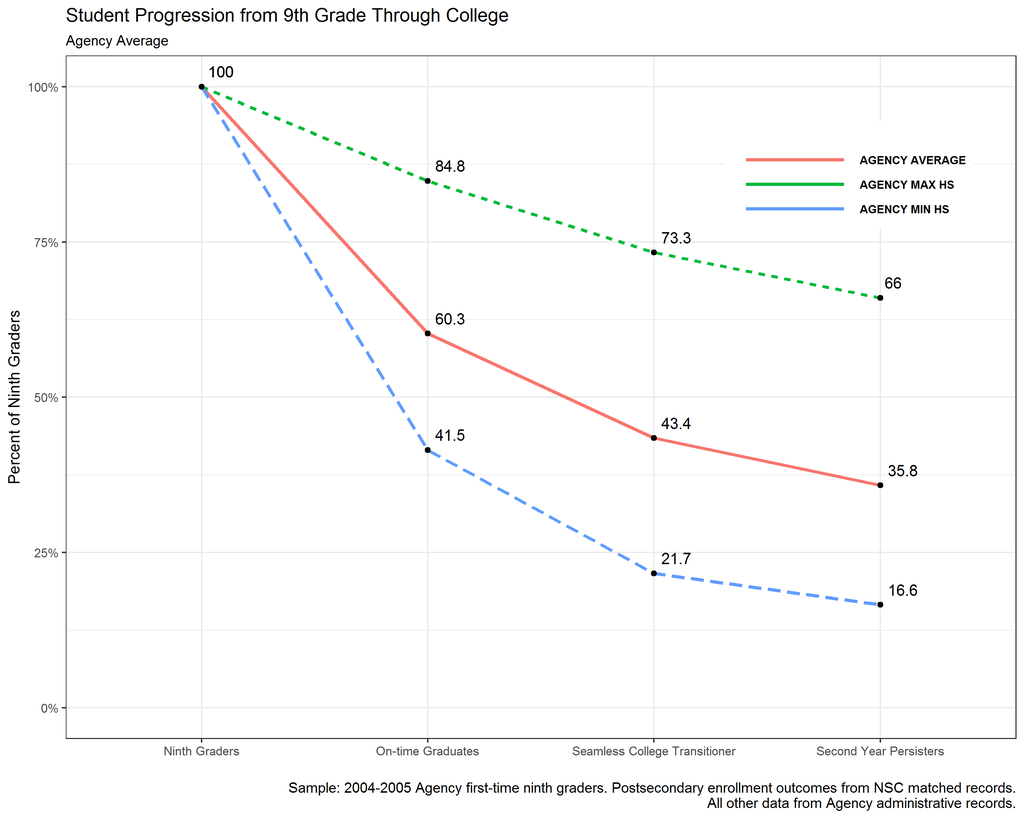

```r
# // Step 6: Format the outcome variables so they read as percentages in the graph

# // Step 7: Reformat the data file so that one variable contains all the outcomes of interest
# // Step 8: Prepare to graph the results
library(tidyr)
schoolData$cohort <- 1
schoolData <- schoolData %>% gather(key = outcome,
                             value = measure, -N, -school_name)
schoolData$subset <- grepl("AGENCY", schoolData$school_name)
library(ggplot2)
library(scales)

schoolData$outcome[schoolData$outcome == "cohort"] <- "Ninth Graders"
schoolData$outcome[schoolData$outcome == "grad"] <- "On-time Graduates"
schoolData$outcome[schoolData$outcome == "seameless_transitioners_any"] <- "Seamless College Transitioner"
schoolData$outcome[schoolData$outcome == "second_year_persisters"] <- "Second Year Persisters"

ggplot(schoolData[schoolData$subset,],
       aes(x = outcome, y = measure, group = school_name,
           color = school_name, linetype = school_name)) +
  geom_line(size = 1.1) + geom_point(aes(group = 1), color = I("black")) +
  geom_text(aes(label = round(measure * 100, 1)), vjust = -0.8, hjust = -0.25,
            color = I("black")) +
  scale_y_continuous(limits = c(0, 1), label = percent) +
  theme_bw() + theme(legend.position = c(0.825, 0.825)) +
  guides(color = guide_legend("", keywidth = 6,
                              label.theme = element_text(face = "bold",
                                                         size = 8,
                                                         angle = 0)),
         linetype = "none") +
  labs(y = "Percent of Ninth Graders",
       title = "Student Progression from 9th Grade Through College",
       subtitle = "Agency Average", x = "",
       caption = "Sample: 2004-2005 Agency first-time ninth graders. Postsecondary enrollment outcomes from NSC matched records.
All other data from Agency administrative records.")
```

## Task 2: Progression by Student Race/Ethnicity

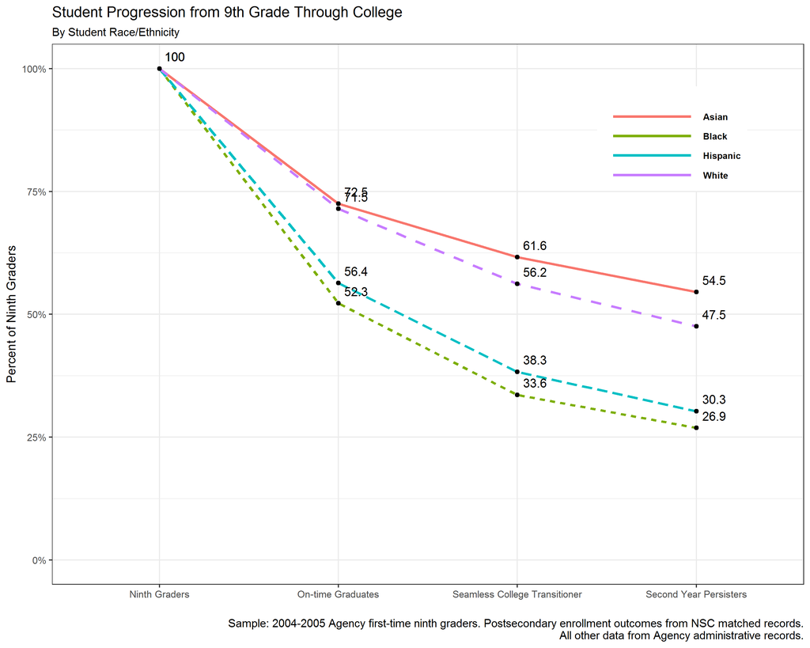

```r
plotdf <- filter(cgdata, chrt_ninth >= chrt_ninth_begin_persist_yr2 & chrt_ninth <= chrt_ninth_end_persist_yr2)

# // Step 3: Create variables for the outcomes "regular diploma recipients", "seamless transitioners" and "second year persisters"
plotdf$grad <- ifelse(!is.na(plotdf$chrt_grad) & plotdf$ontime_grad ==1, 1, 0)
plotdf$seamless_transitioners_any <- as.numeric(plotdf$enrl_1oct_ninth_yr1_any == 1 &
                                                 plotdf$ontime_grad == 1)
plotdf$second_year_persisters = as.numeric(plotdf$enrl_1oct_ninth_yr1_any == 1 &
                                             plotdf$enrl_1oct_ninth_yr2_any == 1 &
                                             plotdf$ontime_grad == 1)
# // Step 4: Create agency-level average outcomes


# // 2. Calculate the mean of each outcome variable by race/ethnicity
progressRace <- plotdf %>% group_by(race_ethnicity) %>%
  summarize(grad = mean(grad),
            seameless_transitioners_any = mean(seamless_transitioners_any, na.rm=TRUE),
            second_year_persisters = mean(second_year_persisters, na.rm=TRUE),
            N = n())

# // Step 7: Reformat the data file so that one variable contains all the outcomes of interest
# // Step 8: Prepare to graph the results
progressRace$cohort <- 1
progressRace <- progressRace %>% gather(key = outcome,
                             value = measure, -N, -race_ethnicity)

progressRace$outcome[progressRace$outcome == "cohort"] <- "Ninth Graders"
progressRace$outcome[progressRace$outcome == "grad"] <- "On-time Graduates"
progressRace$outcome[progressRace$outcome == "seameless_transitioners_any"] <- "Seamless College Transitioner"
progressRace$outcome[progressRace$outcome == "second_year_persisters"] <- "Second Year Persisters"

progressRace$subset <- ifelse(progressRace$race_ethnicity %in% c(1, 3, 2, 5),
                              TRUE, FALSE)
progressRace$race_ethnicity[progressRace$race_ethnicity == 1] <- "Black"
progressRace$race_ethnicity[progressRace$race_ethnicity == 2] <- "Asian"
progressRace$race_ethnicity[progressRace$race_ethnicity == 3] <- "Hispanic"
progressRace$race_ethnicity[progressRace$race_ethnicity == 4] <- "Native American"
progressRace$race_ethnicity[progressRace$race_ethnicity == 5] <- "White"
progressRace$race_ethnicity[progressRace$race_ethnicity == 6] <- "Multiple/Other"
progressRace$race_ethnicity <- as.character(zap_labels(progressRace$race_ethnicity))


ggplot(progressRace[progressRace$subset,],
       aes(x = outcome, y = measure, group = race_ethnicity,
           color = race_ethnicity, linetype = race_ethnicity)) +
  geom_line(size = 1.1) + geom_point(aes(group = 1), color = I("black")) +
  geom_text(aes(label = round(measure * 100, 1)), vjust = -0.8, hjust = -0.25,
            color = I("black")) +
  scale_y_continuous(limits = c(0, 1), label = percent) +
  theme_bw() + theme(legend.position = c(0.825, 0.825)) +
  guides(color = guide_legend("", keywidth = 6,
                              label.theme = element_text(face = "bold",
                                                         size = 8,
                                                         angle = 0)),
         linetype = "none") +
  labs(y = "Percent of Ninth Graders",
       title = "Student Progression from 9th Grade Through College",
       subtitle = "By Student Race/Ethnicity", x = "",
       caption = "Sample: 2004-2005 Agency first-time ninth graders. Postsecondary enrollment outcomes from NSC matched records.
All other data from Agency administrative records.")
```

## Task 3: Progression by Student Race/Ethnicity, Among FRPL-Eligible Students

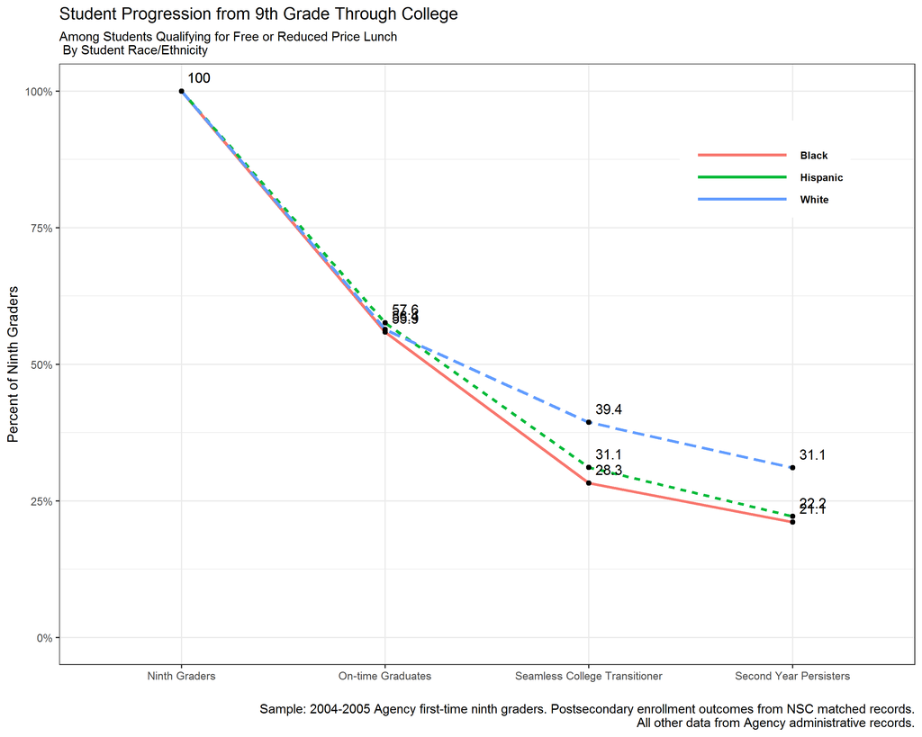

```r
#TODO: equal to 1 seems wrong
## TODO: Graduation seems way off
plotdf <- filter(cgdata, chrt_ninth >= chrt_ninth_begin_persist_yr2 & chrt_ninth <= chrt_ninth_end_persist_yr2) %>% filter(frpl_ever_hs > 0)

# // Step 3: Create variables for the outcomes "regular diploma recipients", "seamless transitioners" and "second year persisters"
plotdf$grad <- ifelse(!is.na(plotdf$chrt_grad) & plotdf$ontime_grad == 1, 1, 0)
plotdf$seamless_transitioners_any <- ifelse(plotdf$enrl_1oct_ninth_yr1_any == 1 &
                                                 plotdf$ontime_grad == 1, 1, 0)
plotdf$second_year_persisters = ifelse(plotdf$enrl_1oct_ninth_yr1_any == 1 &
                                             plotdf$enrl_1oct_ninth_yr2_any == 1 &
                                             plotdf$ontime_grad == 1, 1, 0)
# // Step 4: Create agency-level average outcomes


# // 2. Calculate the mean of each outcome variable by race/ethnicity
progressRaceFRL <- plotdf %>% group_by(race_ethnicity) %>%
  summarize(grad = mean(grad),
            seameless_transitioners_any = mean(seamless_transitioners_any, na.rm=TRUE),
            second_year_persisters = mean(second_year_persisters, na.rm=TRUE),
            N = n())
progressRaceFRL %<>% filter(N >= 20)

# // Step 7: Reformat the data file so that one variable contains all the outcomes of interest
# // Step 8: Prepare to graph the results
progressRaceFRL$cohort <- 1
progressRaceFRL <- progressRaceFRL %>% gather(key = outcome,
                             value = measure, -N, -race_ethnicity)

progressRaceFRL$outcome[progressRaceFRL$outcome == "cohort"] <- "Ninth Graders"
progressRaceFRL$outcome[progressRaceFRL$outcome == "grad"] <- "On-time Graduates"
progressRaceFRL$outcome[progressRaceFRL$outcome == "seameless_transitioners_any"] <- "Seamless College Transitioner"
progressRaceFRL$outcome[progressRaceFRL$outcome == "second_year_persisters"] <- "Second Year Persisters"

# TODO: Recode race
progressRaceFRL$subset <- ifelse(progressRaceFRL$race_ethnicity %in% c(1, 3, 5),
                              TRUE, FALSE)
progressRaceFRL$race_ethnicity[progressRaceFRL$race_ethnicity == 1] <- "Black"
progressRaceFRL$race_ethnicity[progressRaceFRL$race_ethnicity == 2] <- "Asian"
progressRaceFRL$race_ethnicity[progressRaceFRL$race_ethnicity == 3] <- "Hispanic"
progressRaceFRL$race_ethnicity[progressRaceFRL$race_ethnicity == 4] <- "Native American"
progressRaceFRL$race_ethnicity[progressRaceFRL$race_ethnicity == 5] <- "White"
progressRaceFRL$race_ethnicity[progressRaceFRL$race_ethnicity == 6] <- "Multiple/Other"
progressRaceFRL$race_ethnicity <- as.character(zap_labels(progressRaceFRL$race_ethnicity))


ggplot(progressRaceFRL[progressRaceFRL$subset,],
       aes(x = outcome, y = measure, group = race_ethnicity,
           color = race_ethnicity, linetype = race_ethnicity)) +
  geom_line(size = 1.1) + geom_point(aes(group = 1), color = I("black")) +
  geom_text(aes(label = round(measure * 100, 1)), vjust = -0.8, hjust = -0.25,
            color = I("black")) +
  scale_y_continuous(limits = c(0, 1), label = percent) +
  theme_bw() + theme(legend.position = c(0.825, 0.825)) +
  guides(color = guide_legend("", keywidth = 6,
                              label.theme = element_text(face = "bold",
                                                         size = 8,
                                                         angle = 0)),
         linetype = "none") +
  labs(y = "Percent of Ninth Graders",
       title = "Student Progression from 9th Grade Through College",
       subtitle = "Among Students Qualifying for Free or Reduced Price Lunch \n By Student Race/Ethnicity", x = "",
       caption = "Sample: 2004-2005 Agency first-time ninth graders. Postsecondary enrollment outcomes from NSC matched records.
All other data from Agency administrative records.")
```

## Task 4: Progression by Students’ On-Track Status After Ninth Grade

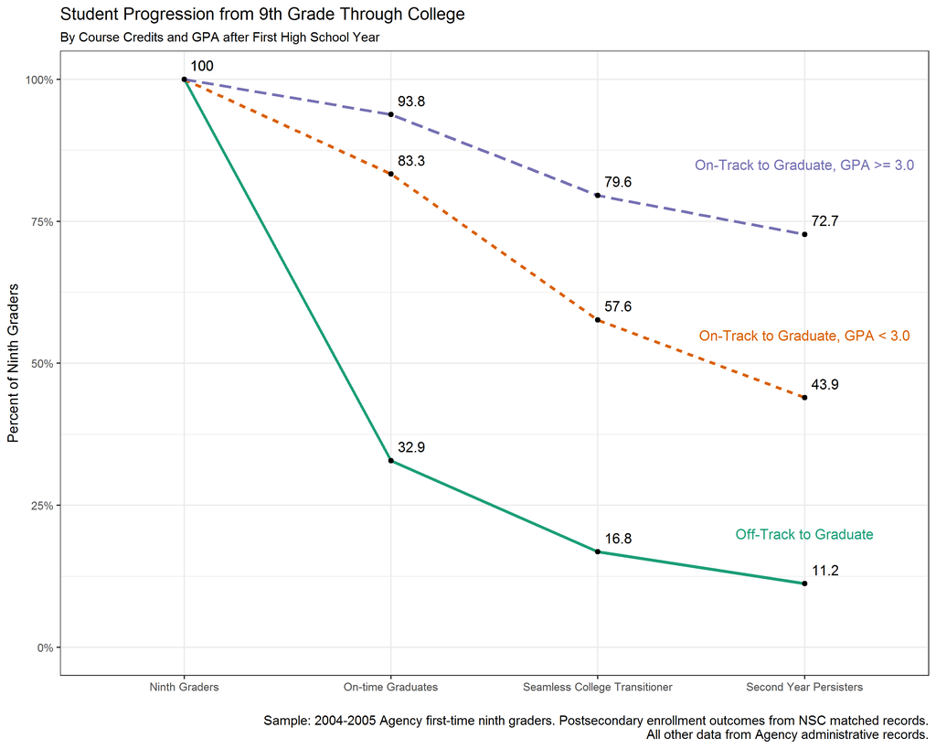

```r
plotdf <- filter(cgdata, chrt_ninth >= chrt_ninth_begin_persist_yr2 & chrt_ninth <= chrt_ninth_end_persist_yr2) %>% filter(ontrack_sample == 1)

# // Step 3: Create variables for the outcomes "regular diploma recipients", "seamless transitioners" and "second year persisters"
plotdf$grad <- ifelse(!is.na(plotdf$chrt_grad) & plotdf$ontime_grad ==1, 1, 0)
plotdf$seamless_transitioners_any <- as.numeric(plotdf$enrl_1oct_ninth_yr1_any == 1 &
                                                 plotdf$ontime_grad == 1)
plotdf$second_year_persisters = as.numeric(plotdf$enrl_1oct_ninth_yr1_any == 1 &
                                             plotdf$enrl_1oct_ninth_yr2_any == 1 &
                                             plotdf$ontime_grad == 1)
# // Step 4: Create agency-level average outcomes


# // 2. Calculate the mean of each outcome variable by race/ethnicity

# // Step 3: Generate on track indicators that take into account students’ GPAs
# upon completion of their first year in high school

plotdf$ot <- NA
plotdf$ot[plotdf$ontrack_endyr1 == 0] <- "Off-Track to Graduate"
plotdf$ot[plotdf$ontrack_endyr1 == 1 & plotdf$cum_gpa_yr1 < 3 & !is.na(plotdf$cum_gpa_yr1)] <- "On-Track to Graduate, GPA < 3.0"
plotdf$ot[plotdf$ontrack_endyr1 == 1 & plotdf$cum_gpa_yr1 >= 3 & !is.na(plotdf$cum_gpa_yr1)] <- "On-Track to Graduate, GPA >= 3.0"

# assert !mi(ontrack_endyr1_gpa) if !mi(ontrack_endyr1) & !mi(cum_gpa_yr1)


progressTrack <- plotdf %>% group_by(ot) %>%
  summarize(grad = mean(grad),
            seameless_transitioners_any = mean(seamless_transitioners_any, na.rm=TRUE),
            second_year_persisters = mean(second_year_persisters, na.rm=TRUE),
            N = n())

# // Step 7: Reformat the data file so that one variable contains all the outcomes of interest
# // Step 8: Prepare to graph the results
progressTrack$cohort <- 1
progressTrack <- progressTrack %>% gather(key = outcome,
                             value = measure, -N, -ot)

# TODO: Function to recode outcome
progressTrack$outcome[progressTrack$outcome == "cohort"] <- "Ninth Graders"
progressTrack$outcome[progressTrack$outcome == "grad"] <- "On-time Graduates"
progressTrack$outcome[progressTrack$outcome == "seameless_transitioners_any"] <- "Seamless College Transitioner"
progressTrack$outcome[progressTrack$outcome == "second_year_persisters"] <- "Second Year Persisters"

# Annotate for direct labels

ann_txt <- data.frame(outcome = rep("Second Year Persisters", 3),
                      measure = c(0.2, 0.55, 0.85),
                      textlabel = c("Off-Track to Graduate",
                                    "On-Track to Graduate, GPA < 3.0",
                                    "On-Track to Graduate, GPA >= 3.0"))
ann_txt$ot <- ann_txt$textlabel

ggplot(progressTrack,
       aes(x = outcome, y = measure, group = ot,
           color = ot, linetype = ot)) +
  geom_line(size = 1.1) + geom_point(aes(group = 1), color = I("black")) +
  geom_text(aes(label = round(measure * 100, 1)), vjust = -0.8, hjust = -0.25,
            color = I("black")) +
  geom_text(data = ann_txt, aes(label = textlabel)) +
  scale_y_continuous(limits = c(0, 1), label = percent) +
  theme_bw() + theme(legend.position = c(0.825, 0.825)) +
  scale_color_brewer(type = "qual", palette = 2) +
  guides(color = "none",
         linetype = "none") +
  labs(y = "Percent of Ninth Graders",
       title = "Student Progression from 9th Grade Through College",
       subtitle = "By Course Credits and GPA after First High School Year", x = "",
       caption = "Sample: 2004-2005 Agency first-time ninth graders. Postsecondary enrollment outcomes from NSC matched records.
All other data from Agency administrative records.")
```

# B: Ninth to Tenth Grade Transition by On-Track Status

## Task 1 Proportion of Students On-Track at the End of Ninth Grade by High School

Purpose: This analysis illustrates what percent of students are on-track after ninth grade graduate from each high school and the agency as a whole. Different levels of on-track for graduation are distinguished by high school.

Analysis-Specific Sample Restrictions: Keep students in ninth grade cohorts you can observe graduating high school on time AND are part of the on-track sample (attended the first semester of ninth grade and never transferred into or out of the system).

Ask Yourself - How does the percent of students on-track differ by high school (consider the overall height of each bar)? - How does the percent of students on-track for an advanced versus general diploma differ by high school (consider the different components of each bar)?

Possible Next Steps or Action Plans: Overall school-level results can be disaggregated by student subgroups of interest, (race, FRPL status, and eighth grade academic achievement).

Analytic Technique:Calculate the proportion of students on-track at each school, and across the agency.

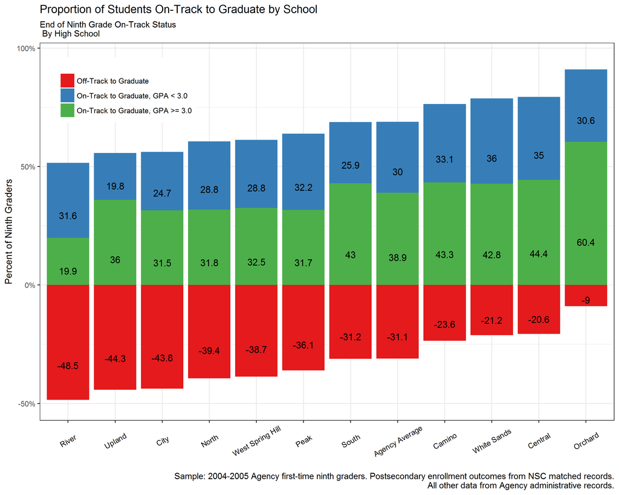

```r
plotdf <- filter(cgdata, chrt_ninth >= chrt_ninth_begin_persist_yr2 & chrt_ninth <= chrt_ninth_end_persist_yr2) %>% filter(ontrack_sample == 1)

# // Step 3: Create variables for the outcomes "regular diploma recipients", "seamless transitioners" and "second year persisters"
plotdf$grad <- ifelse(!is.na(plotdf$chrt_grad) & plotdf$ontime_grad ==1, 1, 0)
plotdf$seamless_transitioners_any <- as.numeric(plotdf$enrl_1oct_ninth_yr1_any == 1 &
                                                 plotdf$ontime_grad == 1)
plotdf$second_year_persisters = as.numeric(plotdf$enrl_1oct_ninth_yr1_any == 1 &
                                             plotdf$enrl_1oct_ninth_yr2_any == 1 &
                                             plotdf$ontime_grad == 1)
# // Step 3: Generate on track indicators that take into account students’ GPAs
# upon completion of their first year in high school

plotdf$ot <- NA
plotdf$ot[plotdf$ontrack_endyr1 == 0] <- "Off-Track to Graduate"
plotdf$ot[plotdf$ontrack_endyr1 == 1 & plotdf$cum_gpa_yr1 < 3 & !is.na(plotdf$cum_gpa_yr1)] <- "On-Track to Graduate, GPA < 3.0"
plotdf$ot[plotdf$ontrack_endyr1 == 1 & plotdf$cum_gpa_yr1 >= 3 & !is.na(plotdf$cum_gpa_yr1)] <- "On-Track to Graduate, GPA >= 3.0"

# assert !mi(ontrack_endyr1_gpa) if !mi(ontrack_endyr1) & !mi(cum_gpa_yr1)
# // Step 4: Obtain the agency average for the key variables
# // Step 5: Obtain mean rates for each school and append the agency average
progressBars <- bind_rows(
  plotdf %>% group_by(ot) %>% tally() %>% ungroup %>%
    mutate(count = sum(n), first_hs_name = "Agency Average"),
  plotdf %>% group_by(first_hs_name, ot) %>% tally() %>% ungroup %>%
    group_by(first_hs_name) %>%
    mutate(count = sum(n))
)

# replace first_hs_name = subinstr(first_hs_name, " High School", "", .)
progressBars$first_hs_name <- gsub(" High School", "", progressBars$first_hs_name)

# // Step 7: For students who are off-track upon completion of their first year of high school, convert the values to be
# negative for ease of visualization in the graph

progressBars$n[progressBars$ot == "Off-Track to Graduate"] <-
  -progressBars$n[progressBars$ot == "Off-Track to Graduate"]

# // Step 8: Multiply the average of each outcome by 100 for graphical representation of the rates. Create a variable equal to
# the sum of the two on-track status variables for easier sorting
# foreach var of varlist ontrack_endyr1_1 ontrack_endyr1_2 ontrack_endyr1_3 {
# replace `var' = (`var' * 100)


ggplot(progressBars, aes(x = reorder(first_hs_name, n/count),
                         y = n/count, group = ot)) +
  geom_bar(aes(fill = ot), stat = 'identity') +
  geom_text(aes(label = round(100* n/count, 1)),
            position = position_stack(vjust=0.3)) +
  theme_bw() +
  scale_y_continuous(limits = c(-0.5, 0.95), label = percent,
                    name = "Percent of Ninth Graders") +
  scale_fill_brewer(name = "", type = "qual", palette = 6) +
  theme(axis.text.x = element_text(angle = 30, color = "black", vjust = 0.5),
        legend.position = c(0.15, 0.875)) +
  labs(title = "Proportion of Students On-Track to Graduate by School",
       subtitle = "End of Ninth Grade On-Track Status \n By High School", x = "",
       caption = "Sample: 2004-2005 Agency first-time ninth graders. Postsecondary enrollment outcomes from NSC matched records.
All other data from Agency administrative records.")
```

## Task 2: Ninth To Tenth Grade Transition by On-Track Status

Purpose: This analysis explores how on-track status after ninth grade (the horizontal axis) predicts ontrack status in tenth grade (the vertical axis). This analysis is useful for developing early dropout warning indicators for at-risk students as early as the second semester of ninth grade.

Analysis-Specific Sample Restrictions: Keep students in ninth grade cohorts you can observe graduating high school on time AND are part of the on-track sample (attended the first semester of ninth grade and never transferred into or out of the system).

Ask Yourself - What percent of those in a specific on-track category at the end of ninth grade stay in that same on-track category? For example, what percent of off-track ninth graders continue off-track in tenth grade? - How might you use an early warning system to help students get back on-track for graduation?

Possible Next Steps or Action Plans: Identify additional risk factors, (chronic absenteeism, prior academic achievement etc.) which can be incorporated into analyses like the one above. This could be used to further understand which students struggle, why they struggle, and interventions to keep them enrolled and engaged.

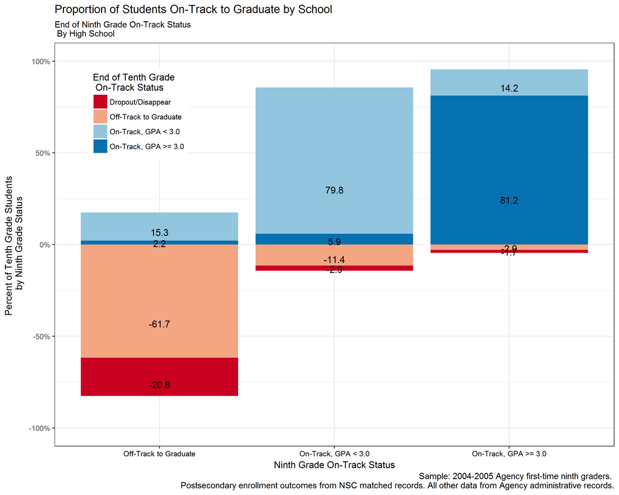

```r
plotdf <- filter(cgdata, chrt_ninth >= chrt_ninth_begin_persist_yr2 &
                   chrt_ninth <= chrt_ninth_end_persist_yr2) %>%
  filter(ontrack_sample == 1)

# // Step 3: Create variables for the outcomes "regular diploma recipients", "seamless transitioners" and "second year persisters"
plotdf$grad <- ifelse(!is.na(plotdf$chrt_grad) & plotdf$ontime_grad ==1, 1, 0)
plotdf$seamless_transitioners_any <- as.numeric(plotdf$enrl_1oct_ninth_yr1_any == 1 &
                                                 plotdf$ontime_grad == 1)
plotdf$second_year_persisters = as.numeric(plotdf$enrl_1oct_ninth_yr1_any == 1 &
                                             plotdf$enrl_1oct_ninth_yr2_any == 1 &
                                             plotdf$ontime_grad == 1)
# // Step 3: Generate on track indicators that take into account students’ GPAs
# upon completion of their first year in high school

plotdf$ot <- NA
plotdf$ot[plotdf$ontrack_endyr1 == 0] <- "Off-Track to Graduate"
plotdf$ot[plotdf$ontrack_endyr1 == 1 & plotdf$cum_gpa_yr1 < 3 & !is.na(plotdf$cum_gpa_yr1)] <- "On-Track, GPA < 3.0"
plotdf$ot[plotdf$ontrack_endyr1 == 1 & plotdf$cum_gpa_yr1 >= 3 & !is.na(plotdf$cum_gpa_yr1)] <- "On-Track, GPA >= 3.0"

# assert !mi(ontrack_endyr1_gpa) if !mi(ontrack_endyr1) & !mi(cum_gpa_yr1)
# // Step 4: Create indicators for students upon completion of their second year of high school

plotdf$ot_10 <- NA

plotdf$ot_10[plotdf$ontrack_endyr2 == 0] <- "Off-Track to Graduate"
plotdf$ot_10[plotdf$ontrack_endyr2 == 1 & plotdf$cum_gpa_yr2 < 3 & !is.na(plotdf$cum_gpa_yr2)] <- "On-Track, GPA < 3.0"
plotdf$ot_10[plotdf$ontrack_endyr2 == 1 & plotdf$cum_gpa_yr2 >= 3 & !is.na(plotdf$cum_gpa_yr2)] <- "On-Track, GPA >= 3.0"
plotdf$ot_10[plotdf$status_after_yr2 == 3 | plotdf$status_after_yr2 == 4] <- "Dropout/Disappear"



# // Step 5: Obtain mean rates for each school and append the agency average
onTrackBar <- plotdf %>% group_by(ot, ot_10) %>%
  select(ot) %>% tally() %>%
  ungroup %>% group_by(ot) %>%
  mutate(count = sum(n))


# // Step 7: For students who are off-track upon completion of their first year of high school, convert the values to be
# negative for ease of visualization in the graph

onTrackBar$n[onTrackBar$ot_10 == "Off-Track to Graduate"] <-
  -onTrackBar$n[onTrackBar$ot_10 == "Off-Track to Graduate"]


onTrackBar$n[onTrackBar$ot_10 == "Dropout/Disappear"] <-
  -onTrackBar$n[onTrackBar$ot_10 == "Dropout/Disappear"]


# // Step 8: Multiply the average of each outcome by 100 for graphical representation of the rates. Create a variable equal to
# the sum of the two on-track status variables for easier sorting
# foreach var of varlist ontrack_endyr1_1 ontrack_endyr1_2 ontrack_endyr1_3 {
# replace `var' = (`var' * 100)


ggplot(onTrackBar, aes(x = reorder(ot, n/count),
                         y = n/count, group = ot_10)) +
  geom_bar(aes(fill = ot_10), stat = 'identity') +
  geom_text(aes(label = round(100* n/count, 1)),
            position = position_stack(vjust=0.3)) +
  theme_bw() +
  scale_y_continuous(limits = c(-1, 1), label = percent,
                    name = "Percent of Tenth Grade Students \n by Ninth Grade Status") +
  scale_fill_brewer(name = "End of Tenth Grade \n On-Track Status",
                    type = "div", palette = 5) +
  theme(axis.text.x = element_text(color = "black"),
        legend.position = c(0.15, 0.825)) +
  labs(title = "Proportion of Students On-Track to Graduate by School",
       x = "Ninth Grade On-Track Status",
       subtitle = "End of Ninth Grade On-Track Status \n By High School",
       caption = paste0("Sample: 2004-2005 Agency first-time ninth graders. \n",
                        "Postsecondary enrollment outcomes from NSC matched records. All other data from Agency administrative records."))
```

# C: High School Graduation

Purpose: This analysis explores variation in high school completion rates across high schools in the system for both on-time and late high school graduates.

Analysis-Specific Sample Restrictions: Keep students in ninth grade cohorts you can observe graduating high school one year late

Ask Yourself - Does the ordering of high school completion rates coincide with beliefs key stakeholders have about these high schools? - Which high schools have the highest and lowest completion rates? Do you know why?

## Task 1: High School Completion Rates By School

Analytic Technique: Calculate the proportion of students who complete high school by school.

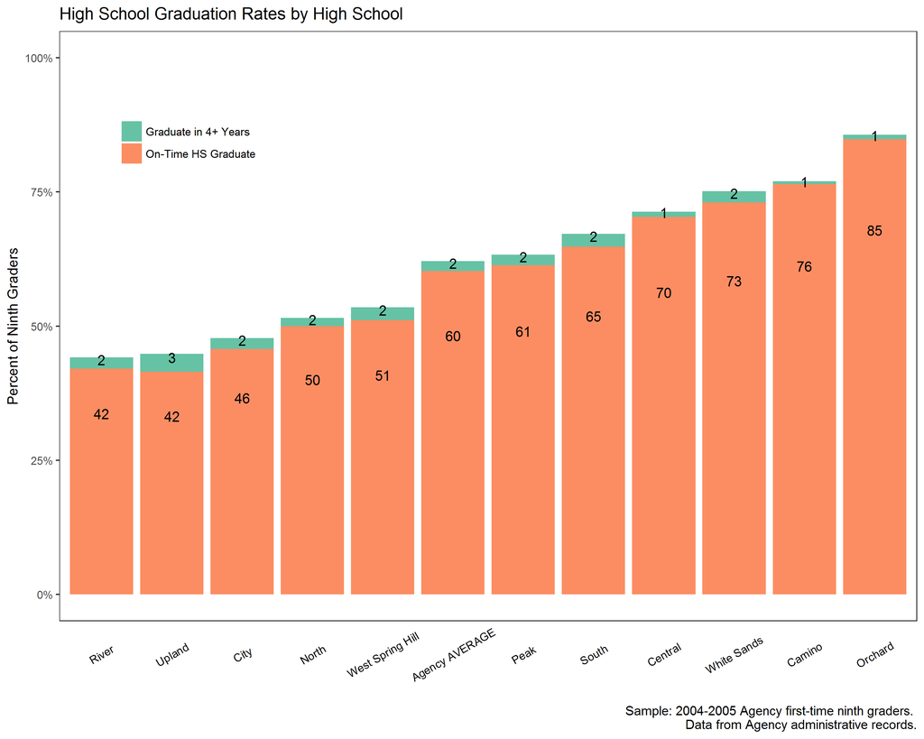

```r
plotdf <- filter(cgdata, chrt_ninth >= chrt_ninth_begin_persist_yr2 &
                   chrt_ninth <= chrt_ninth_end_persist_yr2)

schoolLevel <- bind_rows(
  plotdf %>% group_by(first_hs_name) %>%
    summarize(ontime_grad = mean(ontime_grad, na.rm=TRUE),
              late_grad = mean(late_grad, na.rm=TRUE),
              count = n()),
  plotdf %>% ungroup %>%
    summarize(first_hs_name = "Agency AVERAGE",
              ontime_grad = mean(ontime_grad, na.rm=TRUE),
              late_grad = mean(late_grad, na.rm=TRUE),
              count = n())
)
# // Step 7: Reformat the data file so that one variable contains all the outcomes of interest
# // Step 8: Prepare to graph the results
schoolLevel <- schoolLevel %>% gather(key = outcome,
                             value = measure, -count, -first_hs_name)
schoolLevel$first_hs_name <- gsub(" High School", "", schoolLevel$first_hs_name)

schoolLevel$outcome[schoolLevel$outcome == "ontime_grad"] <- "On-Time HS Graduate"
schoolLevel$outcome[schoolLevel$outcome == "late_grad"] <- "Graduate in 4+ Years"

ggplot(schoolLevel, aes(x = reorder(first_hs_name, measure), y = measure,
                        group = first_hs_name, fill = outcome)) +
  geom_bar(aes(fill = outcome), stat = 'identity') +
  geom_text(aes(label = round(100 * measure, 0)),
            position = position_stack(vjust = 0.8)) +
  theme_bw() + theme(panel.grid = element_blank(), axis.ticks.x = element_blank()) +
  scale_y_continuous(limits = c(0, 1), label = percent,
                    name = "Percent of Ninth Graders") +
  scale_fill_brewer(name = "",
                    type = "qual", palette = 7) +
  theme(axis.text.x = element_text(color = "black", angle = 30, vjust = 0.5),
        legend.position = c(0.15, 0.825)) +
  labs(title = "High School Graduation Rates by High School",
       x = "",
       caption = paste0("Sample: 2004-2005 Agency first-time ninth graders. \n",
                        "Data from Agency administrative records."))
```

## Task 2: High SChool Completion Rates by Average 8th Grade Achievement

```r
plotdf <- filter(cgdata, chrt_ninth >= chrt_ninth_begin_persist_yr2 &
                   chrt_ninth <= chrt_ninth_end_persist_yr2) %>%
  filter(!is.na(test_math_8_std))

schoolLevel <- bind_rows(
  plotdf %>% group_by(first_hs_name) %>%
    summarize(ontime_grad = mean(ontime_grad, na.rm=TRUE),
              std_score = mean(test_math_8_std, na.rm=TRUE),
              count = n()),
  plotdf %>% ungroup %>%
    summarize(first_hs_name = "Agency AVERAGE",
              ontime_grad = mean(ontime_grad, na.rm=TRUE),
              std_score = mean(test_math_8_std, na.rm=TRUE),
              count = n())
)
# // Step 7: Reformat the data file so that one variable contains all the outcomes of interest
# // Step 8: Prepare to graph the results
schoolLevel$first_hs_name <- gsub(" High School", "", schoolLevel$first_hs_name)
```

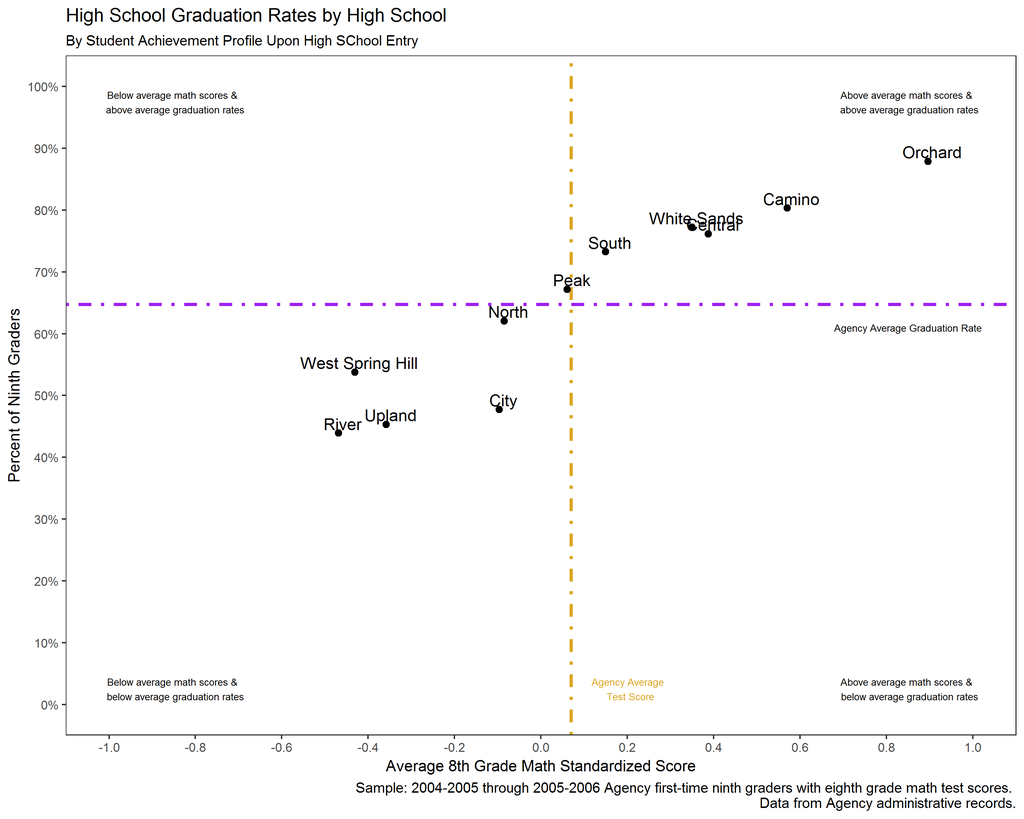

```r
ggplot(schoolLevel[schoolLevel$first_hs_name != "Agency AVERAGE", ],
       aes(x = std_score, y = ontime_grad)) +
  geom_vline(xintercept = as.numeric(schoolLevel[schoolLevel$first_hs_name == "Agency AVERAGE", "std_score"]),
               linetype = 4, color = I("goldenrod"), size = 1.1) +
  geom_hline(yintercept = as.numeric(schoolLevel[schoolLevel$first_hs_name == "Agency AVERAGE", "ontime_grad"]),
               linetype = 4, color = I("purple"), size = 1.1) +
  geom_point(size = I(2)) +
  theme_bw() + theme(panel.grid = element_blank()) +
  coord_cartesian() +
  annotate(geom = "text", x = -.85, y = 0.025,
           label = "Below average math scores & \n below average graduation rates",
           size = I(2.5)) +
  annotate(geom = "text", x = .85, y = 0.025,
           label = "Above average math scores & \n below average graduation rates",
           size = I(2.5)) +
  annotate(geom = "text", x = .85, y = 0.975,
           label = "Above average math scores & \n above average graduation rates",
           size = I(2.5)) +
  annotate(geom = "text", x = -.85, y = 0.975,
           label = "Below average math scores & \n above average graduation rates",
           size = I(2.5)) +
  annotate(geom = "text", x = .205, y = 0.025,
           label = "Agency Average \n Test Score",
           size = I(2.5), color = I("goldenrod")) +
  annotate(geom = "text", x = .85, y = 0.61,
           label = "Agency Average Graduation Rate",
           size = I(2.5)) +
  scale_x_continuous(limits = c(-1, 1), breaks = seq(-1, 1, 0.2)) +
  scale_y_continuous(limits = c(0, 1), label = percent,
                     name = "Percent of Ninth Graders", breaks = seq(0, 1, 0.1)) +
  geom_text(aes(label = first_hs_name), nudge_y = 0.025, vjust = "top", size = I(4),
            nudge_x = 0.01) +
  labs(title = "High School Graduation Rates by High School",
       x = "Average 8th Grade Math Standardized Score",
       subtitle = "By Student Achievement Profile Upon High SChool Entry",
       caption = paste0("Sample: 2004-2005 through 2005-2006 Agency first-time ninth graders with eighth grade math test scores. \n",
                        "Data from Agency administrative records."))
```

## Task 3: High SChool Completion Rates by 8TH Grade Achievement Quartiles

Purpose: This analysis examines variation in completion rates for high schools among students with 8th grade test scores in the same quartile. The analysis is useful to explore high school completion rates across schools with students in the same quartile or range of achievement. Each high school is repeated as a blue bar in each quartile.

Analysis-Specific Sample Restrictions: • Keep students in ninth grade cohorts you can observe graduating high school AND have non-missing eighth grade math scores. • Drop high schools with less than 20 students in each quartile enrolled in ninth grade across the cohorts.

Possible Next Steps or Action Plans: Highlight comparison schools to show variation across quartiles and explore reasons why students at different schools, but with similar academic profiles at high school entry, are more or less likely to graduate.

```r
plotdf <- filter(cgdata, chrt_ninth >= chrt_ninth_begin_persist_yr2 &
                   chrt_ninth <= chrt_ninth_end_persist_yr2) %>%
  filter(!is.na(test_math_8_std))

schoolLevel <- bind_rows(
  plotdf %>% group_by(qrt_8_math, first_hs_name) %>%
    summarize(ontime_grad = mean(ontime_grad, na.rm=TRUE),
              count = n()),
  plotdf %>% ungroup %>%
    summarize(first_hs_name = "Agency AVERAGE",
              qrt_8_math = 1,
              ontime_grad = mean(ontime_grad, na.rm=TRUE),
              count = n())
)
# // Step 7: Reformat the data file so that one variable contains all the outcomes of interest
# // Step 8: Prepare to graph the results
schoolLevel$first_hs_name <- gsub(" High School", "", schoolLevel$first_hs_name)
```

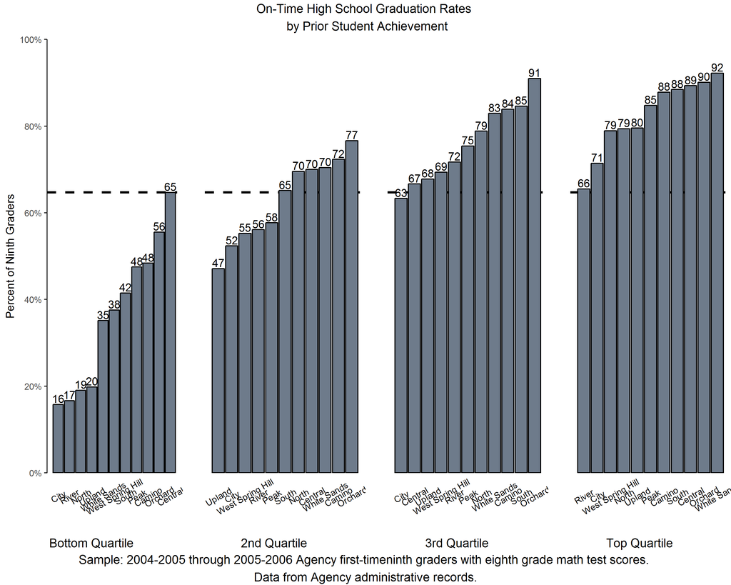

```r
library(gridExtra)
p2 <-  ggplot(schoolLevel[schoolLevel$qrt_8_math == 2 &
                       schoolLevel$first_hs_name != "Agency AVERAGE", ],
       aes(x = reorder(first_hs_name, ontime_grad), y = ontime_grad)) +
      geom_hline(yintercept = as.numeric(schoolLevel$ontime_grad[schoolLevel$first_hs_name == "Agency AVERAGE"]),
               linetype = 2, size = I(1.1)) +
  geom_bar(stat = "identity", fill = "lightsteelblue4", color = I("black")) +
    scale_y_continuous(limits = c(0,1), breaks = seq(0, 1, 0.2),
                       expand = c(0, 0), label = percent) +
    theme_bw() +
    theme(panel.grid = element_blank(),
                       axis.text.x = element_text(angle = 30, color = "black", vjust = 0.5),
          axis.ticks = element_blank(),
          axis.text.y = element_blank(), axis.line.y = element_blank(),
          panel.border = element_blank()) +
    labs(y = "", x = "") +
    geom_text(aes(label = round(ontime_grad * 100, 0)), vjust = -0.2) +
    expand_limits(y = 0, x = 0)

# schoolLevel$order <-

grobList <- list(
  ggplot(schoolLevel[schoolLevel$qrt_8_math == 1 &
                       schoolLevel$first_hs_name != "Agency AVERAGE", ],
       aes(x = reorder(first_hs_name, ontime_grad), y = ontime_grad)) +
        geom_hline(yintercept = as.numeric(schoolLevel$ontime_grad[schoolLevel$first_hs_name == "Agency AVERAGE"]),
               linetype = 2, size = I(1.1)) +
  geom_bar(stat = "identity", fill = "lightsteelblue4", color = I("black")) +
    scale_y_continuous(limits = c(0,1), breaks = seq(0, 1, 0.2),
                       expand = c(0, 0), label = percent) +
    theme_bw() +
    theme(panel.grid = element_blank(),
                       axis.text.x = element_text(angle = 30, color = "black", vjust = 0.5),
          axis.line.y = element_line(),
          axis.ticks.x = element_blank(),panel.border = element_blank()) +
    labs(y = "Percent of Ninth Graders", x = "") +
    geom_text(aes(label = round(ontime_grad * 100, 0)), vjust = -0.2) +
    expand_limits(y = 0, x = 0),
  p2,
  p2 %+% schoolLevel[schoolLevel$qrt_8_math == 3 &
                       schoolLevel$first_hs_name != "Agency AVERAGE", ],
  p2 %+% schoolLevel[schoolLevel$qrt_8_math == 4 &
                       schoolLevel$first_hs_name != "Agency AVERAGE", ]
)

wrap <- mapply(arrangeGrob, grobList,
               bottom = c("Bottom Quartile", "2nd Quartile", "3rd Quartile", "Top Quartile"),
               SIMPLIFY=FALSE)
grid.arrange(grobs=wrap, nrow=1,
             top = "On-Time High School Graduation Rates \n by Prior Student Achievement",
             bottom = paste0("Sample: 2004-2005 through 2005-2006 Agency first-time",
                              "ninth graders with eighth grade math test scores. \n",
                              "Data from Agency administrative records."))
```

## Task 4: Racial Gaps in Completion Overall and by 8th Grade Achievement Quartiles

Purpose: This analysis displays an overall graduation gap by race, and examines the extent to which this gap is explained by average differences in academic achievement between racial sub-groups at high school entry. The analysis is useful to diagnose whether racial gaps in high school result from persistent academic achievement gaps that emerge in early grades, or if other factors unique to the high school experience drive high school completion rate differences by race.

Ask Yourself • How do racial gaps in graduation rates change after prior achievement is accounted for? Do these gaps change for different prior achievement quartiles?

Possible Next Steps or Action Plans: Repeat analyses for only students that qualify for free or reduced price lunch (FRPL) to explore if racial gaps are better explained by disparities in prior academic achievement and family socioeconomic status.

```r
plotdf <- filter(cgdata, chrt_ninth >= chrt_ninth_begin_persist_yr2 &
                   chrt_ninth <= chrt_ninth_end_persist_yr2) %>%
  filter(!is.na(test_math_8_std))

plotdf$race <- as_factor(plotdf$race_ethnicity)

plotOne <- plotdf %>% group_by(race) %>%
  summarize(ontimeGrad = mean(ontime_grad, na.rm = TRUE),
            N = n()) %>% ungroup %>%
  filter(N > 100)

plotTwo <- plotdf %>% group_by(race, qrt_8_math) %>%
  summarize(ontimeGrad = mean(ontime_grad, na.rm=TRUE),
            N = n()) %>% ungroup %>%
  filter(race %in% c("Black", "Asian", "Hispanic", "White"))

plotTwo$qrt_label <- NA
plotTwo$qrt_label[plotTwo$qrt_8_math == 1] <- "Bottom Quartile"
plotTwo$qrt_label[plotTwo$qrt_8_math == 2] <- "2nd Quartile"
plotTwo$qrt_label[plotTwo$qrt_8_math == 3] <- "3rd Quartile"
plotTwo$qrt_label[plotTwo$qrt_8_math == 4] <- "Top Quartile"

plotTwo$qrt_label <- factor(plotTwo$qrt_label,
                            ordered = TRUE,
                            levels = c("Bottom Quartile",
                                       "2nd Quartile",
                                       "3rd Quartile",
                                       "Top Quartile"))

# // Step 7: Reformat the data file so that one variable contains all the outcomes of interest
# // Step 8: Prepare to graph the results
# schoolLevel$first_hs_name <- gsub(" High School", "", schoolLevel$first_hs_name)
```

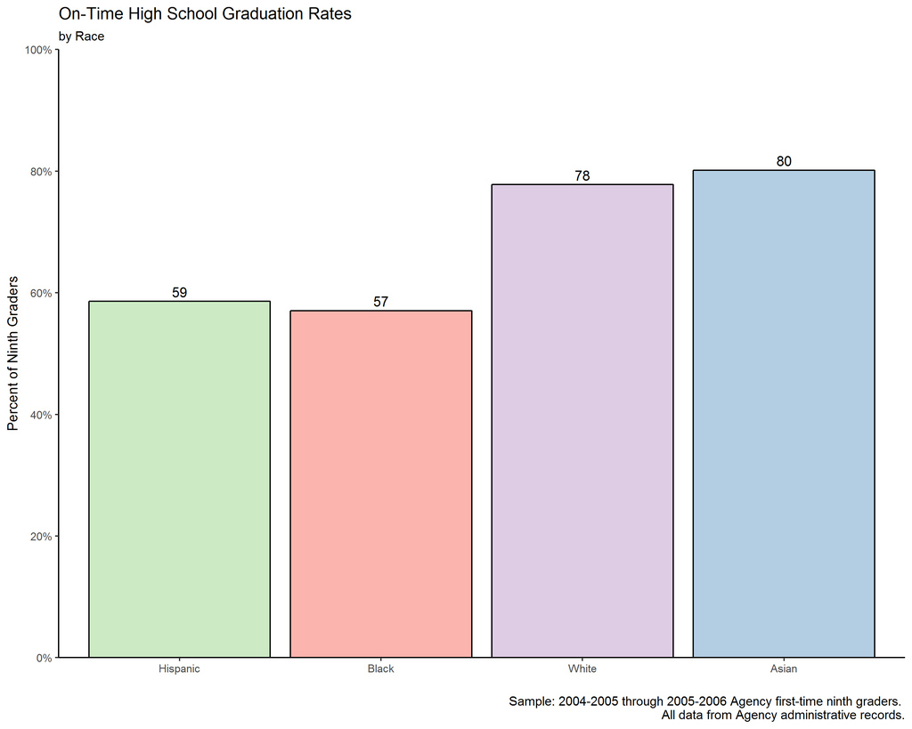

```r
ggplot(plotOne, aes( x= reorder(race, -N), y = ontimeGrad, fill = race)) +
  geom_bar(stat = "identity", color = I("black")) +
  scale_fill_brewer(type = "qual", palette = 4, guide = "none") +
  geom_text(aes(label = round(ontimeGrad*100, 0)), vjust = -0.4) +
  theme_bw() + theme(panel.grid = element_blank(), panel.border = element_blank(),
                     axis.line = element_line()) +
  scale_y_continuous(limits = c(0, 1), expand = c(0, 0),
                     breaks = seq(0, 1, 0.2), name = "Percent of Ninth Graders",
                     label = percent) +
  labs(x = "", title = "On-Time High School Graduation Rates",
       subtitle = "by Race",
       caption = "Sample: 2004-2005 through 2005-2006 Agency first-time ninth graders. \n All data from Agency administrative records.")
```

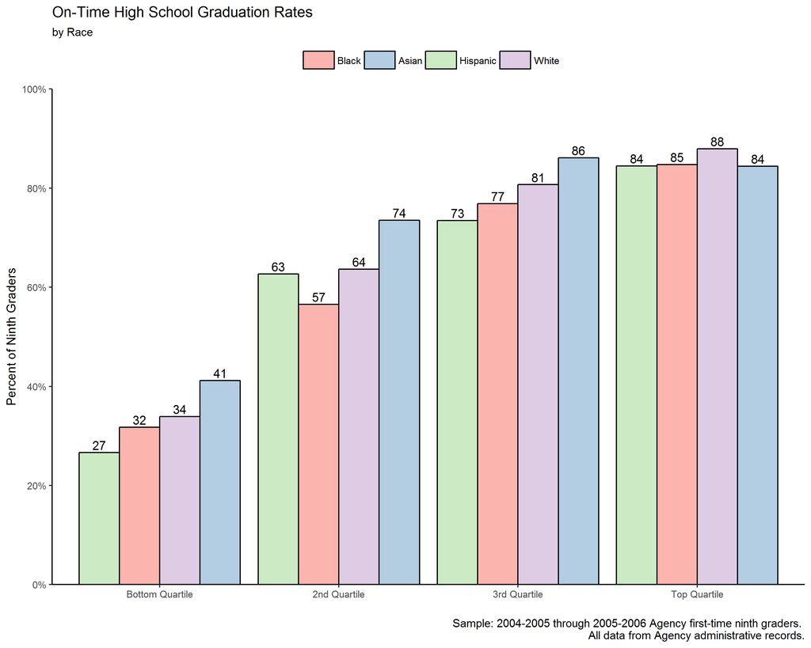

```r
ggplot(plotTwo, aes( x = qrt_label,
                     group= reorder(race, -N), y = ontimeGrad, fill = race)) +
  geom_bar(stat = "identity", color = I("black"), position = "dodge") +
  scale_fill_brewer(type = "qual", palette = 4) +
  guides(fill = guide_legend(nrow=1, title = "", keywidth = 2)) +
  geom_text(aes(label = round(ontimeGrad*100, 0)), position = position_dodge(0.9), vjust = -0.3) +
  theme_bw() + theme(panel.grid = element_blank(), panel.border = element_blank(),
                     axis.line = element_line(), legend.position = "top") +
  scale_y_continuous(limits = c(0, 1), expand = c(0, 0),
                     breaks = seq(0, 1, 0.2), name = "Percent of Ninth Graders",
                     label = percent) +
  labs(x = "", title = "On-Time High School Graduation Rates",
       subtitle = "by Race",
       caption = "Sample: 2004-2005 through 2005-2006 Agency first-time ninth graders. \n All data from Agency administrative records.")
```

## Task 5: Enrollment Outcome in Year Four By On-Track Status At the End of Ninth Grade

Purpose: This analysis explores how strongly student performance in ninth grade predicts high school graduation three years later. Building upon our analysis of the relationship between student performance in ninth and tenth grade, the analysis assesses the utility of using course-level performance data early in students’ high school careers to assess risk of non-completion, and target students in need of academic and/or socio-emotional support.

Analysis-Specific Sample Restrictions: • Keep students in ninth grade cohorts you can observe graduating high school AND are part of the on-track sample (attended the first semester of ninth grade and never transferred into or out of the system).

Ask Yourself • How does on-track status at the end of ninth grade relate to high school completion status at the end of four years?

Possible Next Steps or Action Plans: Repeat analyses for only students that qualify for free or reduced price lunch (FRPL) to explore whether racial gaps are better explained by disparities in prior academic achievement and family socioeconomic status.

```r
plotdf <- filter(cgdata, chrt_ninth >= chrt_ninth_begin_persist_yr2 &
                   chrt_ninth <= chrt_ninth_end_persist_yr2) %>%
  filter(!is.na(cum_gpa_yr1)) %>%
  filter(ontrack_sample == 1)

plotdf$statusVar <- as_factor(plotdf$status_after_yr4)

plotdf$ontrackStatus <- NA
plotdf$ontrackStatus[plotdf$ontrack_endyr1 == 0] <- "Off-Track to Graduate"
plotdf$ontrackStatus[plotdf$ontrack_endyr1 == 1 & plotdf$cum_gpa_yr1 < 3 &
                       !is.na(plotdf$cum_gpa_yr1)] <- "On-Track, GPA < 3.0"
plotdf$ontrackStatus[plotdf$ontrack_endyr1 == 1 & plotdf$cum_gpa_yr1 >= 3 &
                       !is.na(plotdf$cum_gpa_yr1)] <- "On-Track, GPA >= 3.0"



plotOne <- plotdf %>% group_by(ontrackStatus, statusVar) %>%
  summarize(count = n()) %>% ungroup %>%
  group_by(ontrackStatus) %>%
  mutate(sum = sum(count))
plotOne$count[plotOne$statusVar == "Dropped Out"] <- -plotOne$count[plotOne$statusVar == "Dropped Out"]
plotOne$count[plotOne$statusVar == "Disappeared"] <- -plotOne$count[plotOne$statusVar == "Disappeared"]
```

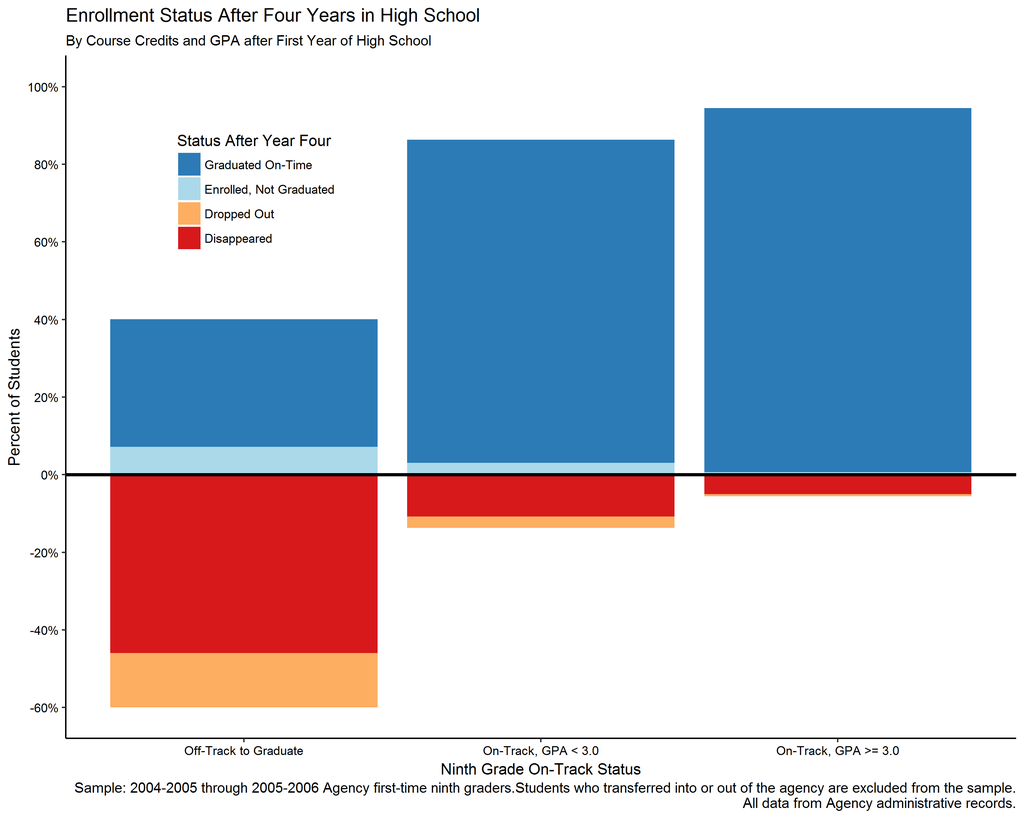

```r
ggplot(plotOne, aes(x = ontrackStatus, y = count/sum, fill = statusVar,
                    group = statusVar)) +
  geom_bar(stat="identity") +
  scale_fill_brewer(type = "div", palette=7, direction = -1) +
  geom_hline(yintercept = 0, size =1.1) +
  scale_y_continuous(limits = c(-0.6, 1), label = percent,
                     breaks = seq(-0.6, 1, 0.2), name = "Percent of Students") +
  labs(x = "Ninth Grade On-Track Status", fill = "Status After Year Four",
       title = "Enrollment Status After Four Years in High School",
       subtitle = "By Course Credits and GPA after First Year of High School",
       caption = paste0("Sample: 2004-2005 through 2005-2006 Agency first-time ninth graders.",
                        "Students who transferred into or out of the agency are excluded from the sample.",
                        "\n All data from Agency administrative records.")) +
  theme_classic() + theme(legend.position = c(0.2, 0.8),
                          axis.text = element_text(color = "black"))
```

# D: College Enrollment

The following three analyses in College Enrollment include the three Strategic Performance Indicators (SPIs) SDP has released to provide deeper insight into the college-going performance of educational systems. These SPIs were conducted using data from a number of SDP’s partner agencies. This section of Analyze will help you conduct these analyses yourself. You can read more about the SPIs at http://www.gse.harvard.edu/sdp/strategic-performance-indicators.

## Task 1: College Enrollment Rates by High School

Purpose: This analysis provides an agency snapshot of college enrollment to understand how patterns of college-going for high school graduates vary across high schools. By illuminating the extent to which enrollment varies by entry time for seamless enrollers and college level (2- vs. 4-year), the analysis helps diagnose compositional differences for the college-bound population by high school attended.

Analysis-Specific Sample Restrictions: • Keep students in high school graduation cohorts you can observe enrolling in college the fall after graduation. • Drop any high schools with less than 20 students in the sample. • Include only graduates who received regular or advanced diplomas (i.e. exclude students who received SPED diplomas and other certificates).

Ask Yourself • How do college enrollment rates differ by high schools? Why might certain schools have a greater percentage of high school graduates enrolling in college? Do certain schools have higher percentages of 2-year or delayed college enrollers?

Possible Next Steps or Action Plans: Replicate this analysis to include all first-time ninth graders (i.e. ninth grade cohorts) in place of graduates. Additionally, create individual high school reports that provide more details for school administrators (top enrolling institutions of the school’s graduates).

```r
plotdf <- cgdata %>% filter(chrt_grad >= chrt_grad_begin & chrt_grad <= chrt_grad_end)

chartData <-
  bind_rows(plotdf %>% select(last_hs_name, enrl_1oct_grad_yr1_2yr, enrl_1oct_grad_yr1_4yr,
                               hs_diploma) %>%
              group_by(last_hs_name) %>%
              summarize_all(funs(sum), na.rm=TRUE),
  plotdf %>% select(enrl_1oct_grad_yr1_2yr, enrl_1oct_grad_yr1_4yr,
                               hs_diploma) %>%
    summarize_all(funs(sum), na.rm=TRUE) %>%
    mutate(last_hs_name = "Agency AVERAGE")
  )

chartData <- chartData %>% gather(key = outcome,
                             value = measure, -last_hs_name, -hs_diploma)

chartData %<>% group_by(last_hs_name) %>%
  mutate(enroll_any = sum(measure) / hs_diploma[1]) %>%
  ungroup

chartData$last_hs_name <- gsub("High School", "", chartData$last_hs_name)
chartData$outcome[chartData$outcome == "enrl_1oct_grad_yr1_2yr"] <- "2-yr Seamless Enroller"
chartData$outcome[chartData$outcome == "enrl_1oct_grad_yr1_4yr"] <- "4-yr Seamless Enroller"
```

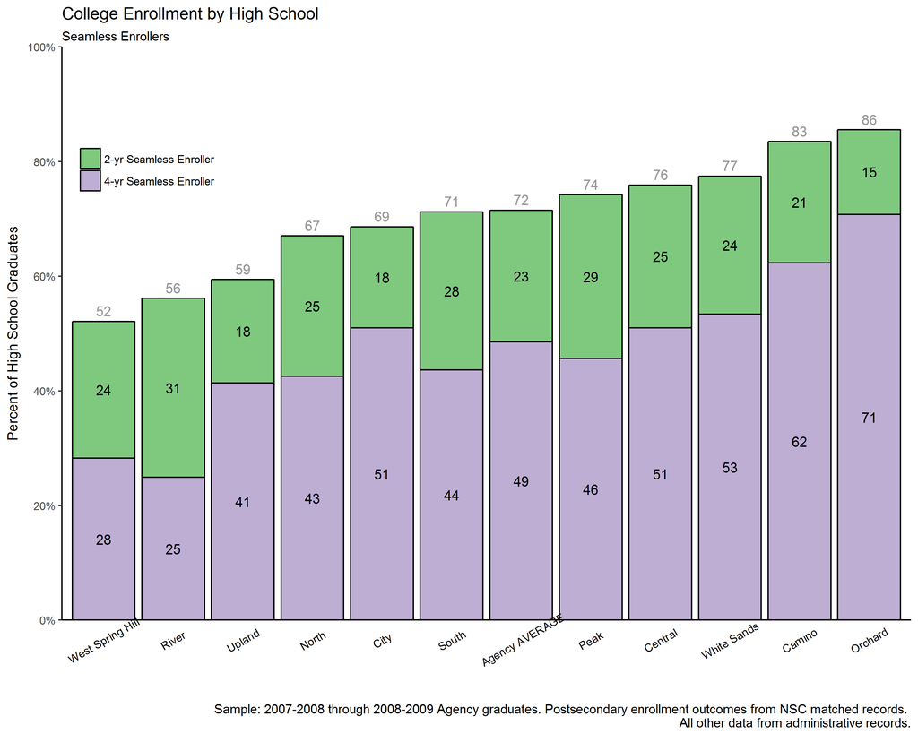

```r
ggplot(chartData, aes(x = reorder(last_hs_name, enroll_any),
                      y = measure/hs_diploma,
                      fill = outcome, group = outcome)) +
  geom_bar(stat = "identity", position = "stack", color = I("black")) +
  geom_text(aes(label = round(100 * measure/hs_diploma)),
            position = position_stack(vjust = 0.5)) +
  geom_text(aes(label = round(100 * enroll_any), y = enroll_any),
            vjust = -0.5, color = I("gray60")) +
  theme_classic() +
  scale_y_continuous(limits = c(0, 1), breaks = seq(0, 1, 0.2),
                     expand = c(0,0),
                     label = percent) +
  scale_fill_brewer(name = "", type = "qual", palette = 1) +
  labs(x = "", y = "Percent of High School Graduates",
       title = "College Enrollment by High School",
       subtitle = "Seamless Enrollers",
       caption = paste0("Sample: 2007-2008 through 2008-2009 Agency graduates. Postsecondary",
                        " enrollment outcomes from NSC matched records. \n ",
                        "All other data from administrative records.")) +
  theme(axis.text.x = element_text(angle = 30, vjust = 0.8, color = "black"),
        legend.position = c(0.1, 0.8), axis.ticks.x = element_blank())
```

## Task 2: Seamless and Delayed College Enrollment Rates by High School

Purpose: This analysis provides an agency snapshot of college enrollment to understand how patterns of college-going for high school graduates vary across high schools. By illuminating the extent to which enrollment varies by entry time (seamless vs. delayed) and college level (2- vs. 4-year), the analysis helps diagnose compositional differences for the college-bound population by high school attended.

Analysis-Specific Sample Restrictions: • Keep students in high school graduation cohorts you can observe enrolling in college the fall after graduation. • Drop any high schools with less than 20 students in the sample. • Include only graduates who received regular or advanced diplomas (i.e. exclude students who received SPED diplomas and other certificates).

Ask Yourself • How do college enrollment rates differ by high schools? Why might certain schools have a greater percentage of high school graduates enrolling in college? Do certain schools have higher percentages of 2-year or delayed college enrollers?

Possible Next Steps or Action Plans: Replicate this analysis to include all first-time ninth graders (i.e. ninth grade cohorts) in place of graduates. Additionally, create individual high school reports that provide more details for school administrators (top enrolling institutions of the school’s graduates).

```r
plotdf <- cgdata %>% filter(chrt_grad >= chrt_grad_begin & chrt_grad <= chrt_grad_end) %>%
  select(sid, chrt_grad, enrl_1oct_grad_yr1_2yr, enrl_1oct_grad_yr1_4yr,
         enrl_1oct_grad_yr1_any, enrl_ever_w2_grad_2yr, enrl_ever_w2_grad_any,
         enrl_ever_w2_grad_4yr, hs_diploma, last_hs_code, last_hs_name)


plotdf$late_any <- ifelse(plotdf$enrl_1oct_grad_yr1_any == 0 &
                            plotdf$enrl_ever_w2_grad_any == 1, 1, 0)
plotdf$late_4yr <- ifelse(plotdf$enrl_1oct_grad_yr1_any == 0 &
                            plotdf$enrl_ever_w2_grad_4yr == 1, 1, 0)
plotdf$late_2yr <- ifelse(plotdf$enrl_1oct_grad_yr1_any == 0 &
                            plotdf$enrl_ever_w2_grad_2yr == 1, 1, 0)


chartData <-
  bind_rows(plotdf %>% select(last_hs_name, enrl_1oct_grad_yr1_2yr,
                              enrl_1oct_grad_yr1_4yr, late_4yr, late_2yr,
                              hs_diploma) %>%
              group_by(last_hs_name) %>%
              summarize_all(funs(sum), na.rm=TRUE),
  plotdf %>% select(enrl_1oct_grad_yr1_2yr,
                              enrl_1oct_grad_yr1_4yr, late_4yr, late_2yr,
                              hs_diploma) %>%
    summarize_all(funs(sum), na.rm=TRUE) %>%
    mutate(last_hs_name = "Agency AVERAGE")
  )

chartData <- chartData %>% gather(key = outcome,
                             value = measure, -last_hs_name, -hs_diploma)

chartData %<>% group_by(last_hs_name) %>%
  mutate(enroll_any = sum(measure) / hs_diploma[1]) %>%
  ungroup

chartData$last_hs_name <- gsub("High School", "", chartData$last_hs_name)
chartData$outcome[chartData$outcome == "enrl_1oct_grad_yr1_2yr"] <- "2-yr Seamless"
chartData$outcome[chartData$outcome == "enrl_1oct_grad_yr1_4yr"] <- "4-yr Seamless"
chartData$outcome[chartData$outcome == "late_2yr"] <- "2-yr Delayed"
chartData$outcome[chartData$outcome == "late_4yr"] <- "4-yr Delayed"
```

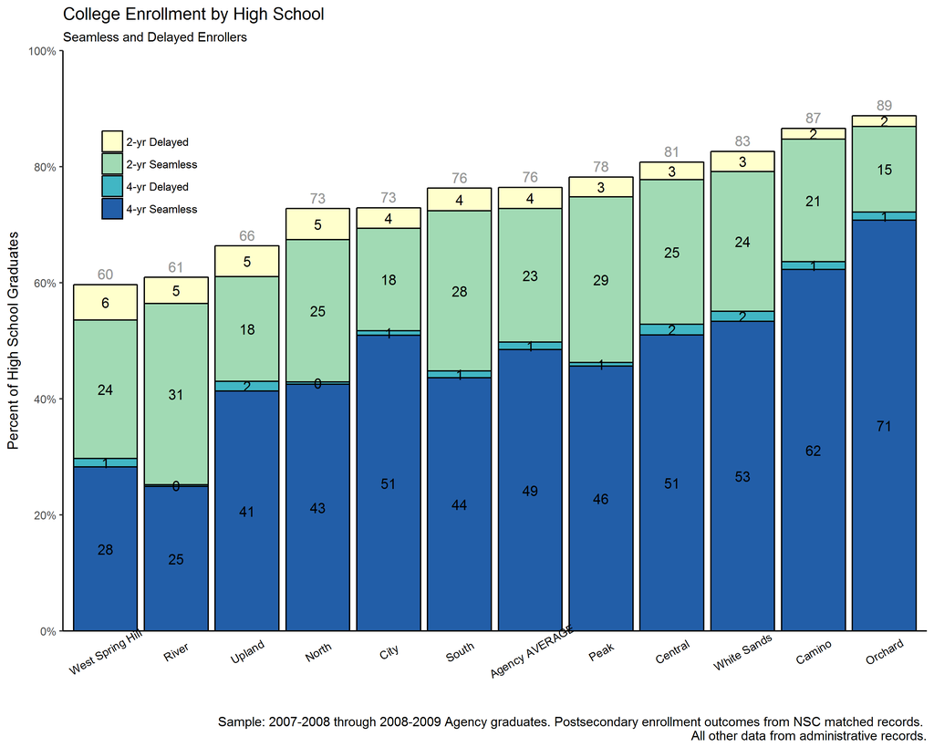

```r
ggplot(chartData, aes(x = reorder(last_hs_name, enroll_any),
                      y = measure/hs_diploma,
                      fill = outcome, group = outcome)) +
  geom_bar(stat = "identity", position = "stack", color = I("black")) +
  geom_text(aes(label = round(100 * measure/hs_diploma)),
            position = position_stack(vjust = 0.5)) +
  geom_text(aes(label = round(100 * enroll_any), y = enroll_any),
            vjust = -0.5, color = I("gray60")) +
  theme_classic() +
  scale_y_continuous(limits = c(0, 1), breaks = seq(0, 1, 0.2),
                     expand = c(0,0),
                     label = percent) +
  scale_fill_brewer(name = "", type = "seq", palette = "YlGnBu") +
  labs(x = "", y = "Percent of High School Graduates",
       title = "College Enrollment by High School",
       subtitle = "Seamless and Delayed Enrollers",
       caption = paste0("Sample: 2007-2008 through 2008-2009 Agency graduates. Postsecondary",
                        " enrollment outcomes from NSC matched records. \n ",
                        "All other data from administrative records.")) +
  theme(axis.text.x = element_text(angle = 30, vjust = 0.8, color = "black"),
        legend.position = c(0.1, 0.8), axis.ticks.x = element_blank())
```

## Task 3: College Enrollment Rates by Average 8th Grade Achievement

Purpose: This analysis displays variations in college enrollment rates across high schools by examining the extent to which academic achievement at high school entry explains variation in college-going across high schools. This analysis is useful to identify high schools with similar incoming student achievement profiles but divergent college enrollment rates; or on the other hand, high schools with similar college-going rates but different academic performance at high school entry.

Analysis-Specific Sample Restrictions: • Keep students in high school graduation cohorts you can observe enrolling in college the fall after graduation AND have non-missing eighth grade test scores. • Include only graduates who received regular or advanced diplomas (i.e. exclude students who received SPED diplomas and other certificates).

Ask Yourself • What might explain variation in college enrollment rates for high schools with similar incoming achievement? What might explain variation in incoming achievement for high schools with similar college enrollment rates?

```r
plotdf <- cgdata %>% filter(chrt_grad >= chrt_grad_begin & chrt_grad <= chrt_grad_end) %>%
  select(sid, chrt_grad, enrl_1oct_grad_yr1_any, test_math_8_std,
         last_hs_name) %>%
  filter(!is.na(test_math_8_std))


AGENCYLEVEL <- plotdf %>%
  summarize(agency_mean_enroll = mean(enrl_1oct_grad_yr1_any, na.rm=TRUE),
            agency_mean_test = mean(test_math_8_std)) %>%
  as.data.frame


chartData <- plotdf %>% group_by(last_hs_name) %>%
  summarize(math_test = mean(test_math_8_std),
            enroll_rate = mean(enrl_1oct_grad_yr1_any, na.rm=TRUE),
            count = n())

chartData$last_hs_name <- gsub("High School", "", chartData$last_hs_name)
```

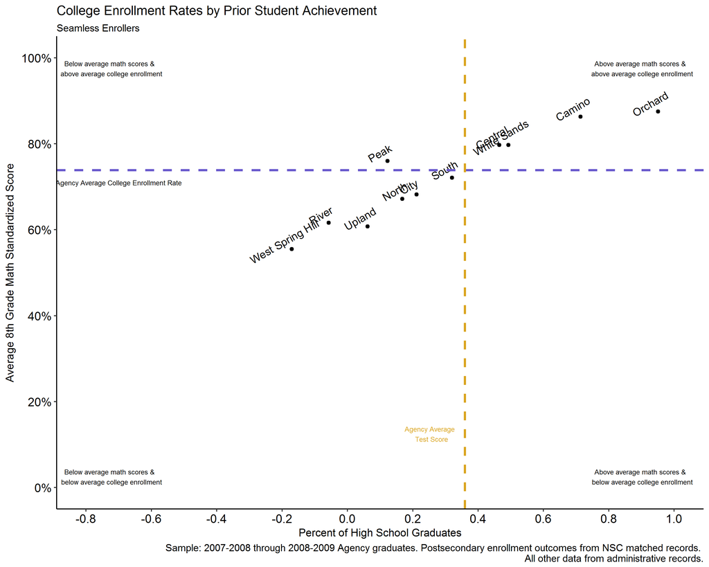

```r
ggplot(chartData, aes(x = math_test, y = enroll_rate)) +
  geom_point() + geom_text(aes(label = last_hs_name),
                           nudge_x = -0.02, nudge_y= 0.02, angle = 30,
                           check_overlap = FALSE) +
  theme_classic() +
  geom_hline(yintercept = AGENCYLEVEL$agency_mean_enroll, linetype = 2,
             size = I(1.1), color = I("slateblue")) +
  geom_vline(xintercept = AGENCYLEVEL$agency_mean_test, linetype = 2,
             size = I(1.1), color = I("goldenrod")) +
  scale_y_continuous(limits = c(0,1), breaks = seq(0, 1, 0.2), label = percent) +
  scale_x_continuous(limits = c(-0.8, 1), breaks = seq(-0.8, 1, 0.2)) +
  annotate(geom = "text", x = -.725, y = 0.025,
           label = "Below average math scores & \n below average college enrollment",
           size = I(2.5)) +
  annotate(geom = "text", x = .9, y = 0.025,
           label = "Above average math scores & \n below average college enrollment",
           size = I(2.5)) +
  annotate(geom = "text", x = .9, y = 0.975,
           label = "Above average math scores & \n above average college enrollment",
           size = I(2.5)) +
  annotate(geom = "text", x = -.725, y = 0.975,
           label = "Below average math scores & \n above average college enrollment",
           size = I(2.5)) +
  annotate(geom = "text", x = .255, y = 0.125,
           label = "Agency Average \n Test Score",
           size = I(2.5), color = I("goldenrod")) +
  annotate(geom = "text", x = -.7, y = 0.71,
           label = "Agency Average College Enrollment Rate",
           size = I(2.5)) +
  labs(x = "Percent of High School Graduates",
       y = "Average 8th Grade Math Standardized Score",
       title = "College Enrollment Rates by Prior Student Achievement",
       subtitle = "Seamless Enrollers",
       caption = paste0("Sample: 2007-2008 through 2008-2009 Agency graduates. Postsecondary",
                        " enrollment outcomes from NSC matched records. \n ",
                        "All other data from administrative records.")) +
  theme(axis.text = element_text(color="black", size = 12))
```

## Task 4: College Enrollment Rates by 8th Grade Achievement Quartiles

Purpose: This analysis explores whether variation in college enrollment across high schools is similar among low-, middle, and top-achieving students. It also considers whether overall variation across schools derives from concentrated divergence among students scoring in a particular achievement range. Additionally, the analysis facilitates granular school-to-school comparisons to identify those especially under-, or over-performing within each achievement quartile. Finally, the analysis also helps identify which student subgroups require additional resources and support within each school.

Analysis-Specific Sample Restrictions: • Keep students in high school graduation cohorts you can observe enrolling in college the fall after graduation AND have non-missing eighth grade test scores. • Drop high schools with less than 20 students in each quartile enrolled in ninth grade across the cohorts. • Keep only graduates who received regular or advanced diplomas (i.e. exclude students who received SPED diplomas and other certificates).

Possible Next Steps or Action Plans: Repeat this analysis to include all first-time ninth graders (i.e. ninth grade cohorts) in place of graduates, and explore college enrollment within two years of high school completion. Additionally, replicate this analysis to explore the relationship between college enrollment and students’ ELA achievement at high school entry. Consider why schools with similar incoming student profiles may report dramatically different college-going rates. Conversely, consider why schools with distinct student bodies may report similar matriculation rates to college.

```r
plotdf <- cgdata %>% filter(chrt_grad >= chrt_grad_begin & chrt_grad <= chrt_grad_end) %>%
  select(sid, chrt_grad, enrl_1oct_grad_yr1_any, qrt_8_math,
         last_hs_name) %>%
  filter(!is.na(qrt_8_math))


AGENCYLEVEL <- plotdf %>%
  summarize(agency_mean_enroll = mean(enrl_1oct_grad_yr1_any, na.rm=TRUE)) %>%
  as.data.frame

chartData <- bind_rows(
  plotdf %>% group_by(last_hs_name, qrt_8_math) %>%
  summarize(enroll_rate = mean(enrl_1oct_grad_yr1_any, na.rm=TRUE),
            count = n()),
  plotdf %>% group_by(qrt_8_math) %>%
  summarize(enroll_rate = mean(enrl_1oct_grad_yr1_any, na.rm=TRUE),
            count = n(),
            last_hs_name = "Agency AVERAGE")
)

chartData$last_hs_name <- gsub("High School", "", chartData$last_hs_name)
```

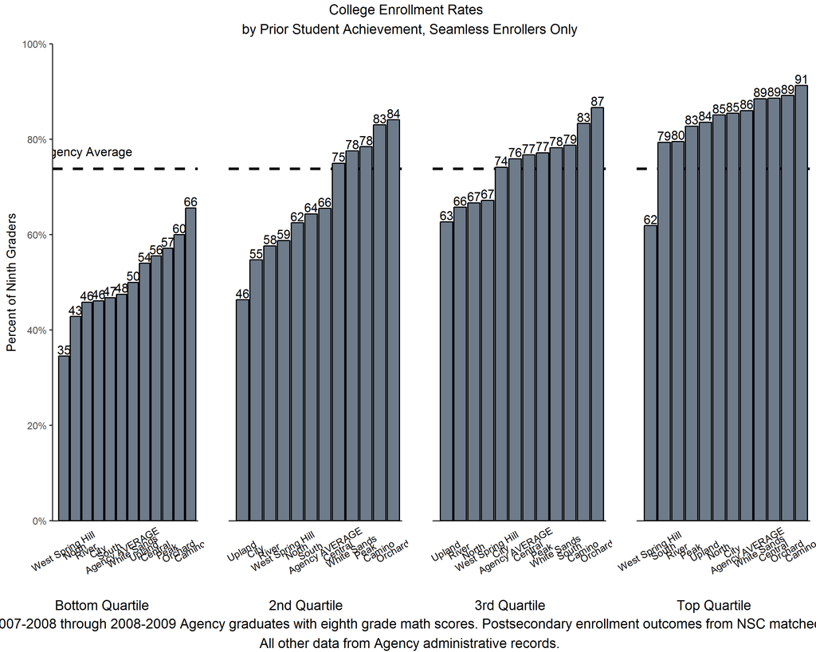

```r
p1 <- ggplot(chartData[chartData$qrt_8_math == 1, ],
       aes(x = reorder(last_hs_name, enroll_rate), y = enroll_rate)) +
        geom_hline(yintercept = as.numeric(AGENCYLEVEL$agency_mean_enroll),
               linetype = 2, size = I(1.1)) +
  geom_bar(stat = "identity", fill = "lightsteelblue4", color = I("black")) +
    scale_y_continuous(limits = c(0,1), breaks = seq(0, 1, 0.2),
                       expand = c(0, 0), label = percent) +
    theme_bw() +
  annotate(geom = "text", x = 3, y = 0.775, label = "Agency Average") +
    theme(panel.grid = element_blank(),
                       axis.text.x = element_text(angle = 30, color = "black", vjust = 0.5),
          axis.line.y = element_line(),  axis.line.x = element_line(),
          axis.ticks.x = element_blank(),panel.border = element_blank()) +
    labs(y = "Percent of Ninth Graders", x = "") +
    geom_text(aes(label = round(enroll_rate * 100, 0)), vjust = -0.2) +
    expand_limits(y = 0, x = 0)

p2 <-  ggplot(chartData[chartData$qrt_8_math == 2, ],
       aes(x = reorder(last_hs_name, enroll_rate), y = enroll_rate)) +
      geom_hline(yintercept = as.numeric(AGENCYLEVEL$agency_mean_enroll),
               linetype = 2, size = I(1.1)) +
  geom_bar(stat = "identity", fill = "lightsteelblue4", color = I("black")) +
    scale_y_continuous(limits = c(0,1), breaks = seq(0, 1, 0.2),
                       expand = c(0, 0), label = percent) +
    theme_bw() +
    theme(panel.grid = element_blank(),
                       axis.text.x = element_text(angle = 30, color = "black", vjust = 0.5),
          axis.ticks = element_blank(), axis.line.x = element_line(),
          axis.text.y = element_blank(), axis.line.y = element_blank(),
          panel.border = element_blank()) +
    labs(y = "", x = "") +
    geom_text(aes(label = round(enroll_rate * 100, 0)), vjust = -0.2) +
    expand_limits(y = 0, x = 0)

# schoolLevel$order <-

grobList <- list(
  p1,
  p2,
  p2 %+% chartData[chartData$qrt_8_math == 3, ],
  p2 %+% chartData[chartData$qrt_8_math == 4, ]
)

wrap <- mapply(arrangeGrob, grobList,
               bottom = c("Bottom Quartile", "2nd Quartile", "3rd Quartile", "Top Quartile"),
               SIMPLIFY=FALSE)
grid.arrange(grobs=wrap, nrow=1,
             top = "College Enrollment Rates \n by Prior Student Achievement, Seamless Enrollers Only",
             bottom = paste0("Sample: 2007-2008 through 2008-2009 ",
                             "Agency graduates with eighth grade math scores. Postsecondary ",
                             "enrollment outcomes from NSC matched records.",
                             " \n All other data from Agency administrative records."))
```

## Task 5: Rates of College Enrollment Among Graduates Highly Qualified to Attend Four-Year Colleges, by College Type

Purpose: Research consistently finds wide variation in rates of persistence and completion across postsecondary institutions. This analysis examines whether high school graduates enroll in colleges and universities that provide the right academic fit to maximize their chances of completion. “Match”describes the extent high school graduates with strong academic records attend colleges and universities that allow them to take advantage of their ambition and abilities. While “matching” to an appropriately selective college is only one factor to consider when choosing a postsecondary institution, the implications of under-matching (i.e. lower rates of persistence and degree completion) suggest students should be encouraged to attend realistic, yet challenging postsecondary institutions.

Analysis-Specific Sample Restrictions: • Keep students in high school graduation cohorts you can observe enrolling in college the fall after graduation. • Include only graduates who received regular or advanced diplomas (i.e. exclude students who received SPED diplomas and other certificates). • Include only highly qualified high school graduates (i.e. students who have obtained a high school diploma on time with 1) a cumulative GPA of 3.0 or higher and Math/Verbal SAT score of 1300 or higher, or 2) a cumulative GPA of 3.3 or higher and Math/Verbal SAT score of 1200 or higher, or 3) a cumulative GPA of 3.7 or higher and Math/Verbal SAT score of at least 1100). • Drop race/ethnic groups with less than 20 students eligible to attend a four-year university.

Ask Yourself • Among highly qualified students, which race/ethnicities seem to face the greatest undermatch rates?

Possible Next Steps or Action Plans: This analysis leads to important questions that warrant further exploration. What factors drive undermatch differences across student subgroups and high schools? To what extent is undermatching concentrated among first-time college-goers? To what extent is undermatching driven by students’ proximity to 2-year versus 4-year institutions? What college aspirations do incoming ninth graders hold, and do these aspirations change by the time they enter or complete 12th grade? To what extent are teachers, counselors, and administrators supported to work with students to cultivate postsecondary aspirations and weigh factors in the college selection process?

```r
plotdf <- cgdata %>% filter(chrt_grad >= chrt_grad_begin & chrt_grad <= chrt_grad_end) %>%
  select(sid, chrt_grad, race_ethnicity, highly_qualified,
         enrl_1oct_grad_yr1_any, enrl_1oct_grad_yr1_4yr, enrl_1oct_grad_yr1_2yr)

plotdf$race_ethnicity <- as_factor(plotdf$race_ethnicity)

totalCount <- nrow(plotdf)

plotdf$no_college <- ifelse(plotdf$enrl_1oct_grad_yr1_any == 0, 1, 0)
plotdf$enrl_2yr <- ifelse(plotdf$enrl_1oct_grad_yr1_2yr == 1, 1, 0)
plotdf$enrl_4yr <- ifelse(plotdf$enrl_1oct_grad_yr1_4yr == 1, 1, 0)

agencyLevel <- plotdf %>% filter(highly_qualified == 1) %>%
  summarize(no_college = mean(no_college, na.rm=TRUE),
            enrl_2yr = mean(enrl_2yr, na.rm=TRUE),
            enrl_4yr = mean(enrl_4yr, na.rm=TRUE),
            total_count = n(),
            race_ethnicity = "TOTAL")

chartData <- plotdf %>% filter(highly_qualified == 1) %>%
  group_by(race_ethnicity) %>%
  summarize(no_college = mean(no_college, na.rm=TRUE),
            enrl_2yr = mean(enrl_2yr, na.rm=TRUE),
            enrl_4yr = mean(enrl_4yr, na.rm=TRUE),
            total_count = n())

chartData <- bind_rows(chartData, agencyLevel)

chartData$no_college <- -chartData$no_college
chartData$enrl_2yr <- -chartData$enrl_2yr

chartData <- chartData %>% gather(key = outcome, value = measure,
                                  -race_ethnicity, -total_count)

chartData$groupPer <- round(100 * chartData$total_count/totalCount)
chartData$race_ethnicity[chartData$race_ethnicity == "Black"] <- "African American"
chartData$race_ethnicity[chartData$race_ethnicity == "Asian"] <- "Asian American"
chartData$race_ethnicity[chartData$race_ethnicity == "Hispanic"] <- "Hispanic American"
chartData$race_ethnicity[chartData$race_ethnicity == "TOTAL"] <- "Total"

chartData$label <- paste0(chartData$race_ethnicity, "\n ",
                          chartData$groupPer, "% of Graduates")

chartData %<>% filter(chartData$race_ethnicity != "Multiple/Other")

chartData$outcomeLabel <- NA
chartData$outcomeLabel[chartData$outcome == "no_college"] <- "Not Enrolled in College"
chartData$outcomeLabel[chartData$outcome == "enrl_2yr"] <- "Enrolled at 2-Yr College"
chartData$outcomeLabel[chartData$outcome == "enrl_4yr"] <- "Enrolled at 4-Yr College"

chartData$outcomeLabel <- factor(chartData$outcomeLabel,
                                 ordered = TRUE,
                                 levels = c("Enrolled at 4-Yr College",
                                            "Not Enrolled in College",
                                            "Enrolled at 2-Yr College"))
```

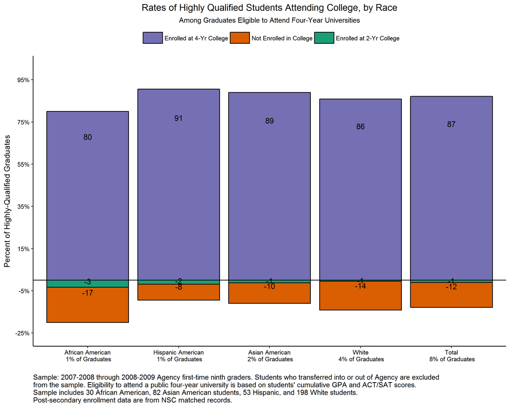

```r
myCap <- paste0("Sample: 2007-2008 through 2008-2009 Agency first-time ninth graders.",
                " Students who transferred into or out of Agency are excluded \n",
                "from the sample. Eligibility to attend a public four-year university",
                  " is based on students' cumulative GPA and ACT/SAT scores. \n",
                  "Sample includes 30 African American, 82 Asian American students, ",
                "53 Hispanic, and 198 White students. \n",
                "Post-secondary enrollment data are from NSC matched records.")

ggplot(chartData, aes(x = reorder(label, total_count), y = measure, group = outcomeLabel,
                      fill = outcomeLabel)) +
  geom_bar(position = 'stack', stat = 'identity', color = I("black")) +
  geom_hline(yintercept = 0) +
  geom_text(aes(label = round(measure * 100, 0)), position=position_stack(vjust = 0.85)) +
  scale_y_continuous(limits = c(-.25, 1), breaks = seq(-.25, 1, 0.2), label = percent) +
  theme_classic() +
  guides(fill = guide_legend(nrow=1, title = "", keywidth = 2)) +
  scale_fill_brewer(type = "qual", palette = 2, direction = -1) +
  theme(legend.position = "top", axis.text = element_text(color = "black"),
        plot.caption = element_text(hjust = 0),
        plot.title = element_text(hjust = 0.5),
        plot.subtitle = element_text(hjust = 0.5)) +
  labs(x = "", y = "Percent of Highly-Qualified Graduates",
       title = "Rates of Highly Qualified Students Attending College, by Race",
       subtitle = "Among Graduates Eligible to Attend Four-Year Universities",
       caption = myCap)
```

## Task 6: Gaps in Rates of College Enrollment Between Latino High School Graduates and White High SChool Graduates

Purpose: This Strategic Performance Indicator explores gaps in college enrollment rates by ethnicity, before and after accounting for differences in prior academic achievement, socioeconomic status, and both of these background characteristics. While the analysis evaluates separately the college enrollment gaps between Black and White students and between Latino and White students, it can be modified to focus on the gap between any two races or ethnicities.

Analysis-Specific Sample Restrictions: • Keep students in high school graduation cohorts you can observe enrolling in college the fall after graduation. • Keep only graduates who received regular or advanced diplomas (i.e. exclude students who received SPED diplomas and other certificates). • Drop race/ethnic groups with less than 20 students eligible to attend a four-year university. You may further restrict the sample to only include students from the most representative racial/ethnic sub-groups in your agency.

Ask Yourself • How do racial gaps in college enrollment change after prior achievement is accounted for? How do these gaps change after socioeconomic status is accounted for? • Do these gaps still exist when you account for both prior achievement and socioeconomic status? Do they reverse direction, suggesting that minority students enroll in college at higher rates when compared with White students with similar background characteristics? • Do you observe differences in the degree to which the White-Black gap and the White-Latino gap decline after accounting for prior achievement and socioeconomic status? If the adjusted gap between White and Latino students, for example, is still sizeable, what additional barriers may be impeding access to college for Latino students?

Analytic Technique: Calculate the difference between the proportion of Black (or Latino) high school graduates and the proportion of White high school graduates who enrolled in college—in raw terms and after accounting for 8th grade test scores, for eligibility for Free or Reduced Price Lunch (FRPL), and for both of these characteristics.

```r
plotdf <- cgdata %>% filter(chrt_grad >= chrt_grad_begin & chrt_grad <= chrt_grad_end) %>%
  select(sid, chrt_grad, race_ethnicity, test_math_8, frpl_ever,
         enrl_1oct_grad_yr1_any, last_hs_code) %>%
  filter(!is.na(frpl_ever) & !is.na(test_math_8)) %>%
  filter(race_ethnicity %in% c(1, 3, 5) & !is.na(race_ethnicity)) %>%
  filter(!is.na(enrl_1oct_grad_yr1_any))

plotdf$race_ethnicity <- as_factor(plotdf$race_ethnicity)
plotdf$race_ethnicity <- relevel(plotdf$race_ethnicity, ref = "White")
plotdf$cluster_var <- paste(plotdf$chrt_grad, plotdf$last_hs_code, sep = "-")

library(broom)
# Estimate unadjusted enrollment gap
mod1 <- lm(enrl_1oct_grad_yr1_any ~ race_ethnicity, data = plotdf)
betas_unadj <- tidy(mod1)
# Cluster?
clusterSE <- get_CL_vcov(mod1, plotdf$cluster_var)
betas_unadj$std.error <- sqrt(diag(clusterSE))
betas_unadj <- betas_unadj[, 1:3]
betas_unadj$model <- "Unadjusted enrollment gap"
# Estimate enrollment gap adjusting for prior achievement
mod2 <- lm(enrl_1oct_grad_yr1_any ~ race_ethnicity + test_math_8, data = plotdf)
betas_adj_prior_ach <- tidy(mod2)
# Cluster?
clusterSE <- get_CL_vcov(mod2, plotdf$cluster_var)
betas_adj_prior_ach$std.error <- sqrt(diag(clusterSE))
betas_adj_prior_ach <- betas_adj_prior_ach[, 1:3]
betas_adj_prior_ach$model <- "Gap adjusted for prior achievement"
# Estimate enrollment gap adjusting for frpl status
plotdf$frpl_ever <- ifelse(plotdf$frpl_ever > 0, 1, 0)
mod3 <- lm(enrl_1oct_grad_yr1_any ~ race_ethnicity + frpl_ever, data = plotdf)
betas_adj_frpl <- tidy(mod3)
# Cluster?
clusterSE <- get_CL_vcov(mod3, plotdf$cluster_var)
betas_adj_frpl$std.error <- sqrt(diag(clusterSE))
betas_adj_frpl <- betas_adj_frpl[, 1:3]
betas_adj_frpl$model <- "Gap adjusted for FRPL status"
# Estimate enrollment gap adjusting for prior achievement and frpl status
mod4 <- lm(enrl_1oct_grad_yr1_any ~ race_ethnicity + frpl_ever + test_math_8,
           data = plotdf)
betas_adj_frpl_prior <- tidy(mod4)
# Cluster?
clusterSE <- get_CL_vcov(mod4, plotdf$cluster_var)
betas_adj_frpl_prior$std.error <- sqrt(diag(clusterSE))
betas_adj_frpl_prior <- betas_adj_frpl_prior[, 1:3]
betas_adj_frpl_prior$model <- "Gap adjusted for prior achievement & FRPL status"

chartData <- bind_rows(betas_unadj, betas_adj_frpl, betas_adj_prior_ach,
                    betas_adj_frpl_prior)
rm(plotdf, betas_unadj, betas_adj_frpl, betas_adj_frpl_prior,
   betas_adj_prior_ach)
```

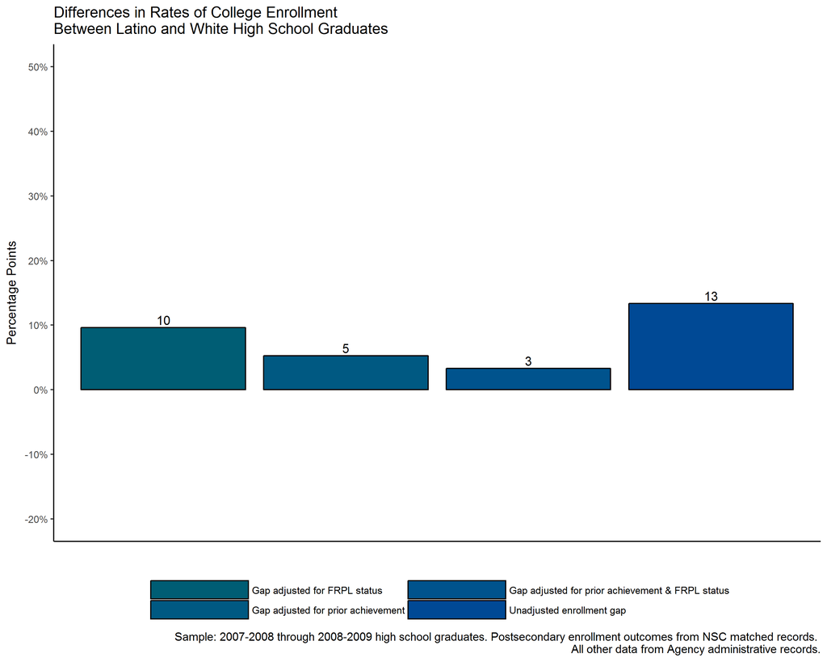

```r
ggplot(chartData[chartData$term == "race_ethnicityHispanic", ],
       aes(x = model, y = -estimate, fill = model)) +
  geom_bar(stat = 'identity', color = I("black")) +
  scale_fill_hue(h = c(210, 250), l = 30, c = 70) +
  guides(fill = guide_legend("", keywidth = 6, nrow = 2)) +
  geom_text(aes(label = round(100 * -estimate, 0)), vjust = -0.3) +
  scale_y_continuous(limits = c(-0.2, 0.5), breaks = seq(-0.2, 0.5, 0.1),
                     label = percent, name = "Percentage Points") +
  theme_classic() + theme(legend.position = "bottom", axis.text.x = element_blank(),
                          axis.ticks.x = element_blank()) +
  labs(title = "Differences in Rates of College Enrollment \nBetween Latino and White High School Graduates",
       x = "",
       caption = "Sample: 2007-2008 through 2008-2009 high school graduates. Postsecondary enrollment outcomes from NSC matched records. \n All other data from Agency administrative records.")
```

## Task 7: College Enrollment Rates by 8th Grade Achievement Quartile Bubbles

Purpose: This SPI highlights the variation in college-going rates across high schools when students with similar prior achievement are compared. To conduct these comparisons, we first sort all incoming ninth-graders into quartiles based on their 8th grade test scores. We then examine college-going rates by high school among graduates within each of these quartiles.

Analysis-Specific Sample Restrictions: • Keep students in high school graduation cohorts you can observe enrolling in college the fall after graduation AND have non-missing eighth grade test scores. • Drop high schools with less than 20 students in each quartile enrolled in ninth grade across the cohorts. • Keep only graduates who received regular or advanced diplomas (i.e. exclude students who received SPED diplomas and other certificates).

Ask Yourself • How do college enrollment rates vary across high schools for students within the same quartile of 8th grade test scores (that is, when we compare students with similar prior achievement)? • What is the difference between the high schools with the lowest and with the highest rates in each quartile? • Are across-school differences in colleges enrollment rates particularly large for students of certain achievement profile—for example, for students with 8th grade test scores in the bottom quartile?

Analytic Technique: Calculate the share of students in each 8th grade test score quartile at each high school who enroll in college seamlessly after high school graduation.

```r
plotdf <- cgdata %>% filter(chrt_grad >= chrt_grad_begin & chrt_grad <= chrt_grad_end) %>%
  select(sid, chrt_grad, qrt_8_math, hs_diploma,
         enrl_1oct_grad_yr1_any, last_hs_name) %>%
  filter(!is.na(qrt_8_math)) %>%
  filter(!is.na(enrl_1oct_grad_yr1_any))

chartData <- plotdf %>% group_by(last_hs_name, qrt_8_math) %>%
  summarize(enroll_count = sum(enrl_1oct_grad_yr1_any),
            diploma_count = sum(hs_diploma)) %>%
  mutate(pct_enrl = enroll_count/diploma_count)

agencyData <- plotdf %>% group_by(qrt_8_math) %>%
  summarize(enroll_count = sum(enrl_1oct_grad_yr1_any),
            diploma_count = sum(hs_diploma)) %>%
  mutate(pct_enrl = enroll_count/diploma_count) %>% as.data.frame
```

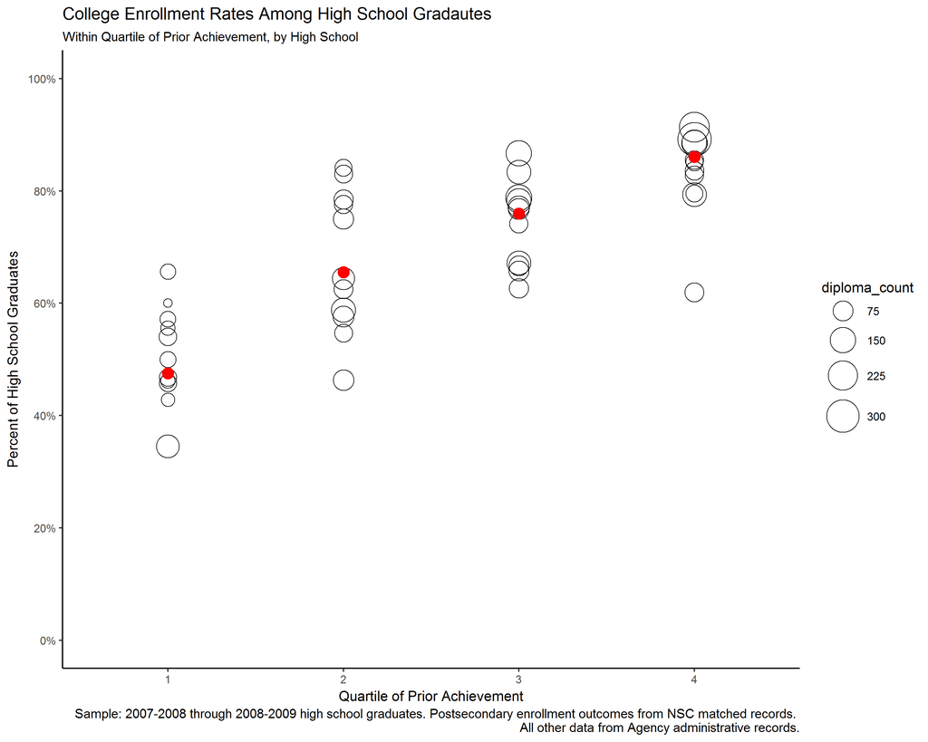

```r
ggplot(chartData, aes(x = factor(qrt_8_math), y = pct_enrl)) +
  geom_point(aes(size = diploma_count), shape = 1) +
  scale_size(range = c(3, 12), breaks = seq(0, 350, 75)) +
  geom_point(data=agencyData, aes(x = factor(qrt_8_math),
                                  y = pct_enrl, size = NULL),
             color = I("red"), size = I(4)) +
  theme_classic() +
  scale_y_continuous(limits = c(0, 1), breaks = seq(0, 1, 0.2), label = percent) +
  labs(y = "Percent of High School Graduates",
       x = "Quartile of Prior Achievement",
       title = "College Enrollment Rates Among High School Gradautes",
       subtitle = "Within Quartile of Prior Achievement, by High School",
        caption = "Sample: 2007-2008 through 2008-2009 high school graduates. Postsecondary enrollment outcomes from NSC matched records. \n All other data from Agency administrative records.")
```

## Task 8: Undermatch Rates Among Highly Qualified High School Graduates

Purpose: This Strategic Performance Indicator examines the prevalence of “undermatch” in the agency—that is, the extent to which high school graduates with strong academic records pursue enrollment in colleges and universities less selective than those for which they are likely qualified. The SPI does so by illustrating the rates at which highly qualified graduates are enrolling at 2-year colleges, less competitive 4-year colleges, or forgoing college altogether, instead of pursuing selective colleges that may provide a better academic and social fit for these students’ potential, ambition, and preparation.

Analysis-Specific Sample Restrictions: • Keep students in high school graduation cohorts you can observe enrolling in college the fall after graduation. • Keep only highly qualified high school graduates (i.e. students who have obtained a high school diploma on time with 1) a cumulative GPA of 3.0 or higher and Math/Verbal SAT score of 1300 or higher, or 2) a cumulative GPA of 3.3 or higher and Math/Verbal SAT score of 1200 or higher, or 3) a cumulative GPA of 3.7 or higher and Math/Verbal SAT score of at least 1100). • Keep only graduates who received regular or advanced diplomas (i.e. exclude students who received SPED diplomas and other certificates).

A Note on College Selectivity To determine the selectivity of the postsecondary institutions in which high school graduates enroll, we typically rely on Barron’s College Rankings. Barron’s has developed well-established college selectivity ratings based on the degree of admissions competitiveness at four-year colleges and universities. Factors used in determining these rankings include the median SAT and ACT scores, high school class rankings, and grade point average among incoming college freshmen. The seven selectivity rankings Barron’s assigns are “Most Competitive,” “Highly Competitive,” “Very Competitive,” “Competitive,” “Less Competitive,” “Non-Competitive,” and “Special.” As part of this exercise, we have provided a simplified table from which the selectivity ratings of the colleges and universities included in this dataset can be obtained. In conducting this analysis for your own agency, you need to select a source of college selectivity ratings, such as Barron’s, and use it in place of the college selectivity table used in this exercise.

Ask Yourself • How do college enrollment rates vary across high schools for students within the same quartile of 8th grade test scores (that is, when we compare students with similar prior achievement)? • What is the difference between the high schools with the lowest and with the highest rates in each quartile? • Are across-school differences in colleges enrollment rates particularly large for students of certain achievement profile—for example, for students with 8th grade test scores in the bottom quartile?

```r
plotdf <- cgdata %>% filter(chrt_grad >= chrt_grad_begin & chrt_grad <= chrt_grad_end) %>%
  select(sid, chrt_grad, highly_qualified, first_college_opeid_4yr,
         enrl_1oct_grad_yr1_any, enrl_1oct_grad_yr1_4yr, enrl_1oct_grad_yr1_2yr) %>%
  filter(!is.na(highly_qualified)) %>%
  filter(highly_qualified ==1 )
# Read in college selectivity data
tmpfileName <- "analysis/college_selectivity.dta"
con <- unz(description = "data/analysis.zip", filename = tmpfileName,
           open = "rb")
coll_select <- read_stata(con) # read data in the data subdirectory
close(con)
plotdf <- left_join(plotdf, coll_select,
                    by = c("first_college_opeid_4yr" = "college_id"))
plotdf %<>% filter(!(first_college_opeid_4yr == "" & enrl_1oct_grad_yr1_4yr == 1))
# Create matching outcomes
# recode rank to avoid issues
plotdf$rank[is.na(plotdf$rank)] <- 6
plotdf$outcome <- NA
plotdf$outcome[plotdf$enrl_1oct_grad_yr1_any == 0] <- "No college"
plotdf$outcome[plotdf$enrl_1oct_grad_yr1_2yr == 1] <- "Two year college"
plotdf$outcome[is.na(plotdf$outcome) &
                 plotdf$enrl_1oct_grad_yr1_any == 1 & (plotdf$rank > 4)] <- "Undermatch"
plotdf$outcome[plotdf$enrl_1oct_grad_yr1_any == 1 & plotdf$rank <= 4] <- "Match"

chartData <- plotdf %>% group_by(outcome) %>%
  summarize(count = n()) %>% ungroup %>%
  mutate(totalCount = sum(count))
```

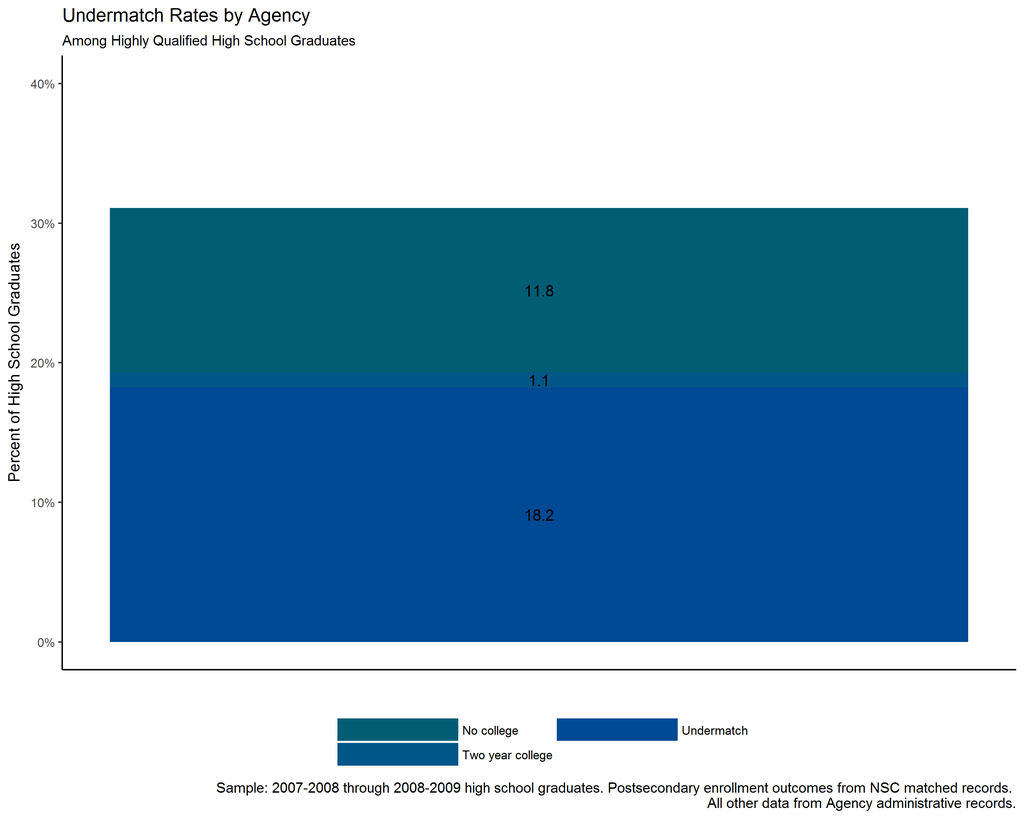

```r
# chartData$outcome <- factor(chartData$outcome, ordered=TRUE,
#                             levels = c("No college",
#                                        "Two year college",
#                                        "Undermatch",
#                                        "Match"))
chartData %<>% filter(outcome != "Match") %>%
  arrange(count)

ggplot(arrange(chartData, -count),
       aes(x = factor(1), fill = outcome, y = count/totalCount)) +
  geom_bar(stat = 'identity', position = "stack") +
  scale_fill_hue(h = c(210, 250), l = 30, c = 70) +
  guides(fill = guide_legend("", keywidth = 6, nrow = 2)) +
  geom_text(aes(label = round(100 * count/totalCount, 1)),
            position = position_stack(vjust = 0.5)) +
  scale_y_continuous(limits = c(0, 0.40), breaks = seq(0, 0.4, 0.1),
                     label = percent, name = "Percent of High School Graduates") +
  theme_classic() + theme(legend.position = "bottom", axis.text.x = element_blank(),
                          axis.ticks.x = element_blank()) +
  labs(title = "Undermatch Rates by Agency",
       subtitle = "Among Highly Qualified High School Graduates",
       x = "",
       caption = "Sample: 2007-2008 through 2008-2009 high school graduates. Postsecondary enrollment outcomes from NSC matched records. \n All other data from Agency administrative records.")
```

# E: College Persistence

For many high school graduates, college enrollment is just the first of many hurdles on the road to postsecondary success. While considerable attention has been paid to challenges that surround college preparedness, access, and enrollment, only recently has conversation expanded to consider barriers to degree completion. These barriers must be understood and addressed at both the secondary and postsecondary levels for college attainment rates to increase. In the last section of the education pipeline, you examine patterns of persistence to the second year of college to identify early indications of student progress towards degree attainment. To explore college persistence, use the models below:

## Task 1: Persistence Rates to the Second Year of College by High School

Purpose: Initial enrollment decisions can dramatically affect higher education trajectories and the likelihood of degree attainment. This analysis provides a snapshot of persistence to the second year of college by examining persistence rates across high schools in the system. The analysis illuminates differences in persistence by level of college first attended (two-year vs. four-year). Given another year of sample data, the analysis could also be conducted by time of initial entry (seamless vs. delayed enrollment).

Analysis-Specific Sample Restrictions: • Keep students in high school graduation cohorts you can observe enrolling in college the fall after graduation • Keep only graduates who received regular or advanced diplomas (i.e. exclude students who received SPED diplomas and other certificates). • Drop high schools with less than 20 students in the sample.

Ask Yourself • How does college persistence for enrollers at 2-year colleges compare to enrollers at 4-year colleges? Given another year of sample data, how does college persistence for seamless enrollers compare to delayed enrollers?

Possible Next Steps or Action Plans: Consider establishing MOUs with local community colleges to obtain detailed data on graduates’ postsecondary pursuits at two-year colleges (Course enrollment and transcript data) allowing agencies to explore persistence rates by assignment to remediation coursework.

```r
plotdf <- cgdata %>% filter(chrt_grad >= chrt_grad_begin & chrt_grad <= chrt_grad_end) %>%
  select(sid, chrt_grad, enrl_1oct_grad_yr1_2yr, enrl_1oct_grad_yr1_4yr,
         enrl_1oct_grad_yr1_any, enrl_grad_persist_any,
         enrl_grad_persist_2yr, enrl_grad_persist_4yr, last_hs_name,
         enrl_ever_w2_grad_any)

plotdf$groupVar <- NA
plotdf$groupVar[plotdf$enrl_1oct_grad_yr1_2yr == 1] <- "2-year College"
plotdf$groupVar[plotdf$enrl_1oct_grad_yr1_4yr == 1] <- "4-year College"

agencyData <- plotdf %>% group_by(groupVar) %>%
  summarize(persistCount = sum(enrl_grad_persist_any, na.rm=TRUE),
            totalCount = n()) %>%
  ungroup %>%
  mutate(total = sum(persistCount)) %>%
  mutate(persistRate = persistCount / totalCount,
         last_hs_name = "Agency AVERAGE")

schoolData <- plotdf %>% group_by(groupVar, last_hs_name) %>%
  summarize(persistCount = sum(enrl_grad_persist_any, na.rm=TRUE),
            totalCount = n()) %>%
  ungroup %>% group_by(last_hs_name) %>%
  mutate(total = sum(persistCount)) %>%
  mutate(persistRate = persistCount / totalCount)

chartData <- bind_rows(agencyData, schoolData)

chartData$last_hs_name <- gsub(" High School", "", chartData$last_hs_name)

chartData <- na.omit(chartData)
chartData <- filter(chartData, totalCount > 20)

chartData <- chartData %>% group_by(groupVar) %>%
  mutate(order = min_rank(-persistRate))
chartData %<>% arrange(last_hs_name)


chartData$order[chartData$groupVar == "2-year College"] <- chartData$order[chartData$groupVar == "4-year College"]

chartData$groupVar <- factor(chartData$groupVar)
chartData$groupVar <- relevel(chartData$groupVar, ref = "4-year College")
```

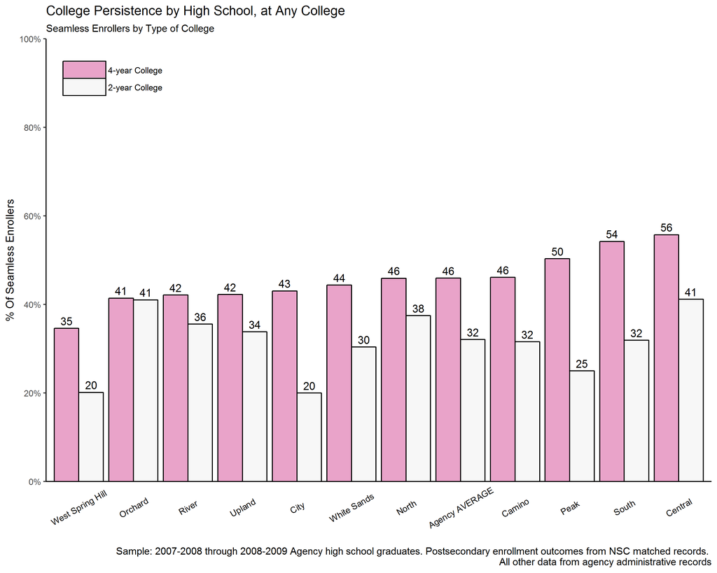

```r
ggplot(chartData, aes(x = reorder(last_hs_name, -order),
                                      group = groupVar,
                      y = persistRate, fill = groupVar,
                      color = I("black"))) +
  geom_bar(stat = 'identity', position = 'dodge') +
  geom_text(aes(label = round(persistRate * 100, 0)),
            position = position_dodge(0.9), vjust = -0.4) +
  scale_y_continuous(limits = c(0, 1), breaks = seq(0, 1, 0.2),
                     name = "% Of Seamless Enrollers",
                     expand = c(0,0), label = percent) +
  theme_classic() +
  guides(fill = guide_legend("", keywidth = 3, nrow = 2)) +
  theme(axis.text.x = element_text(angle = 30, vjust = 0.5, color = "black"),
        legend.position = c(0.1, 0.925), axis.ticks.x = element_blank(),
        legend.key = element_rect(color = "black")) +
  scale_fill_brewer(type = "div", palette = 2) +
  labs(x = "",
       title = "College Persistence by High School, at Any College",
       subtitle = "Seamless Enrollers by Type of College",
       caption = "Sample: 2007-2008 through 2008-2009 Agency high school graduates. Postsecondary enrollment outcomes from NSC matched records. \n All other data from agency administrative records")
```

## Task 2: Persistence Across Two-Year and Four-Year Colleges

Purpose: This analysis provides a snapshot of persistence to the second year of college from one type of college to another for different high schools in the system. The left analysis charts explores how seamless enrollers in 4-year colleges either persist at a 4-year or switch to a 2-year. The right analysis charts how seamless enrollers in 2-year colleges either persist at a 2-year or switch to a 4-year.

Analysis-Specific Sample Restrictions: • Keep the three most recent cohorts of graduates for which persistence in college over four consecutive years can be reported. • Keep only graduates enrolled in 4-yr colleges and universities the fall following high school graduation. • Keep only graduates for whom cumulative high school GPAs can be calculated (or obtained from the agency) • Only include the top six enrolling 4-year colleges • Only report persistence rates among students falling in each high school GPA category if the sample includes 25 or more students

Ask Yourself • How do the rates of persistence or switching differ for seamless enrollers at 4-year vs. 2-year colleges?

Possible Next Steps or Action Plans: Create individual school-level reports for administrators and college counselors to communicate which postsecondary institutions are associated with greater rates of persistence. Additionally, conduct similar analyses that include more detailed institutional information that may be associated with students’ prospects of persisting (e.g. cost of tuition and room/board, financial aid, etc.).

Analytic Technique: Calculate the proportion of 4-yr college-goers who persist through four years of college by the postsecondary institution first attended and cumulative high school GPA category.

```r
plotdf <- cgdata %>% filter(chrt_grad >= chrt_grad_begin & chrt_grad <= chrt_grad_end) %>%
  select(sid, chrt_grad, enrl_1oct_grad_yr1_2yr, enrl_1oct_grad_yr1_4yr,
         enrl_1oct_grad_yr1_any, enrl_1oct_grad_yr2_2yr, enrl_1oct_grad_yr2_4yr,
         enrl_1oct_grad_yr2_any, enrl_grad_persist_any,
         enrl_grad_persist_2yr, enrl_grad_persist_4yr, last_hs_name)

plotdf$persist_pattern <- "Not persisting"
plotdf$persist_pattern[plotdf$enrl_grad_persist_4yr ==1 &
                         !is.na(plotdf$chrt_grad)] <- "Persisted at 4-Year College"
plotdf$persist_pattern[plotdf$enrl_grad_persist_2yr ==1 &
                         !is.na(plotdf$chrt_grad)] <- "Persisted at 2-Year College"
plotdf$persist_pattern[plotdf$enrl_1oct_grad_yr1_4yr == 1 &
                        plotdf$enrl_1oct_grad_yr2_2yr == 1 &
                         !is.na(plotdf$chrt_grad)] <- "Switched to 2-Year College"
plotdf$persist_pattern[plotdf$enrl_1oct_grad_yr1_2yr == 1 &
                        plotdf$enrl_1oct_grad_yr2_4yr == 1 &
                         !is.na(plotdf$chrt_grad)] <- "Switched to 4-Year College"

plotdf$groupVar <- "Non-enroller"
plotdf$groupVar[plotdf$enrl_1oct_grad_yr1_2yr == 1] <- "2-year College"
plotdf$groupVar[plotdf$enrl_1oct_grad_yr1_4yr == 1] <- "4-year College"

chartData <- plotdf %>% filter(groupVar != "Non-enroller") %>%
  group_by(last_hs_name, groupVar, persist_pattern) %>%
  summarize(tally = n()) %>%
  ungroup %>%
  group_by(last_hs_name, groupVar) %>%
  mutate(denominator = sum(tally)) %>%
  mutate(persistRate = tally / denominator) %>%
  filter(persist_pattern != "Not persisting") %>%
  mutate(rankRate = sum(persistRate))

agencyData <- plotdf %>% filter(groupVar != "Non-enroller") %>%
  group_by(groupVar, persist_pattern) %>%
  summarize(tally = n(),
            last_hs_name = "Agency AVERAGE") %>%
  ungroup %>%
  group_by(last_hs_name, groupVar) %>%
  mutate(denominator = sum(tally)) %>%
  mutate(persistRate = tally / denominator) %>%
  filter(persist_pattern != "Not persisting") %>%
  mutate(rankRate = sum(persistRate))

chartData <- bind_rows(chartData, agencyData)


chartData$last_hs_name <- gsub(" High School", "", chartData$last_hs_name)
# chartData %<>% filter(persist_pattern != "Not persisting")
chartData %<>% arrange(persist_pattern)
chartData <- as.data.frame(chartData)
chartData$persist_pattern <- factor(as.character(chartData$persist_pattern),
                                    ordered = TRUE,
                                    levels = c("Switched to 4-Year College",
                                               "Switched to 2-Year College",
                                               "Persisted at 2-Year College",
                                               "Persisted at 4-Year College"))
```

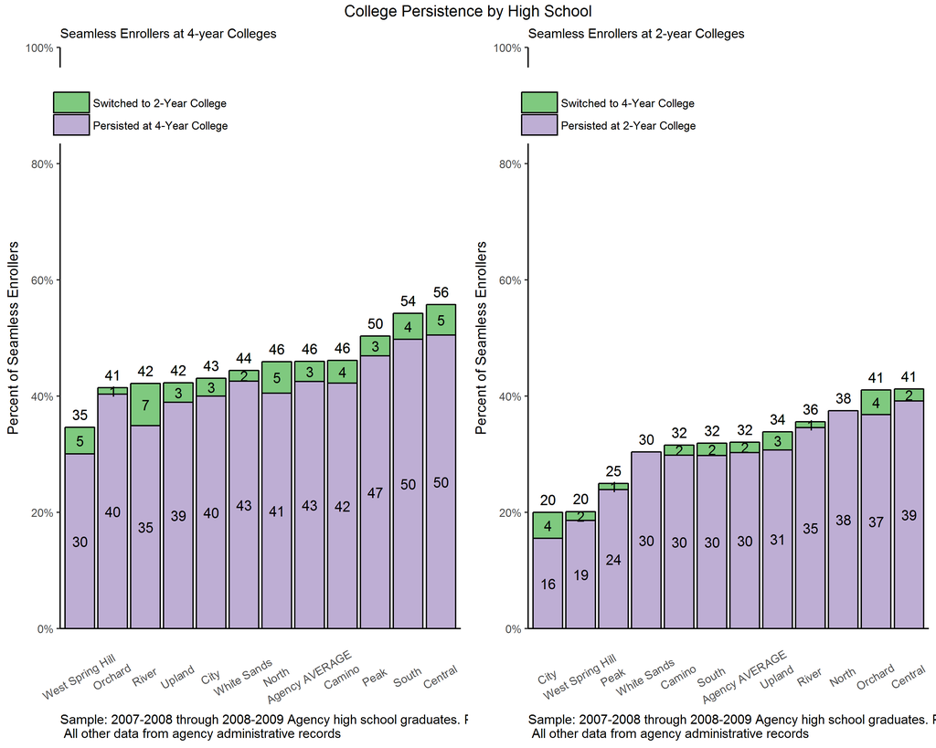

```r
p1 <- ggplot(chartData[chartData$groupVar == "2-year College",],
       aes(x = reorder(last_hs_name, rankRate),
           y = persistRate, group = persist_pattern,
           fill = persist_pattern)) +
  scale_y_continuous(limits = c(0, 1), expand = c(0, 0),
                     label = percent, breaks = seq(0, 1, 0.2)) +
  geom_bar(stat = 'identity', position = 'stack',
           color = I("black")) +
  geom_text(aes(label = round(persistRate * 100, 0)),
            position = position_stack(vjust = 0.5)) +
  geom_text(aes(label = round(rankRate * 100, 0), y = rankRate), vjust = -0.7) +
  guides(fill = guide_legend("", keywidth = 2, nrow = 2)) +
  scale_fill_brewer(type = "qual", palette = 1) +
  labs(x = "", y = "Percent of Seamless Enrollers") +
  theme_classic() + theme(axis.text.x = element_text(angle = 30, vjust = 0.2),
                          axis.ticks.x = element_blank(),
                          legend.position = c(0.2, 0.9),
                          plot.caption = element_text(hjust = 0)) +
  labs(subtitle = "Seamless Enrollers at 2-year Colleges",
       caption = "Sample: 2007-2008 through 2008-2009 Agency high school graduates. Postsecondary enrollment outcomes from NSC matched records. \n All other data from agency administrative records")

p2 <- p1 %+% chartData[chartData$groupVar == "4-year College",] +
  labs(subtitle = "Seamless Enrollers at 4-year Colleges")


grid.arrange(grobs= list(p2, p1), nrow=1,
             top = "College Persistence by High School")
```

## Task 3: Top-Enrolling Colleges/Universities of Agency Graduates

Purpose: This analysis reports enrollment and persistence rates among top-enrolling two- and fouryear institutions attended by graduates. This analysis illuminates differences in persistence rates to the second year of college among top-enrolling postsecondary institutions. Agency staff that advise students during their senior year may find this information useful when meeting to weigh college options.

Analysis-Specific Sample Restrictions: • Keep only the most recent cohort of seamless college-goers for which persistence to the second year of college can be reported • Only include postsecondary institutions with 25 or more agency graduates attending.

Ask Yourself • What are the top enrolling 4-year and 2-year colleges or universities in your agency? What are the persistence rates at those colleges and universities?

Analytic Technique: Calculate the proportion of college-goers attending top-enrolling 2- and 4-year institutions, as well as the proportion of seamless enrollers who persist to the second year of any college, by the postsecondary institution graduates first attended.

```r
plotdf <- cgdata %>% filter(chrt_grad >= chrt_grad_begin & chrt_grad <= chrt_grad_end) %>%
  select(sid, chrt_grad, enrl_1oct_grad_yr1_2yr, enrl_1oct_grad_yr1_4yr,
         enrl_1oct_grad_yr1_any, enrl_1oct_grad_yr2_2yr, enrl_1oct_grad_yr2_4yr,
         enrl_1oct_grad_yr2_any, enrl_grad_persist_any,
         enrl_grad_persist_2yr, enrl_grad_persist_4yr,
         first_college_name_any, first_college_name_2yr, first_college_name_4yr)


chart4year <- bind_rows(
  plotdf %>% group_by(first_college_name_4yr) %>%
  summarize(enrolled = sum(enrl_1oct_grad_yr1_4yr, na.rm=TRUE),
            persisted = sum(enrl_grad_persist_4yr, na.rm=TRUE)) %>%
  ungroup %>%
  mutate(total_enrolled = sum(enrolled)) %>%
  mutate(perEnroll = round(100 * enrolled/total_enrolled, 1),
         perPersist = round(100 * persisted/enrolled, 1)),
  plotdf %>%
  summarize(enrolled = sum(enrl_1oct_grad_yr1_4yr, na.rm=TRUE),
            persisted = sum(enrl_grad_persist_4yr, na.rm=TRUE),
            first_college_name_4yr = "All 4-Year Colleges") %>%
  ungroup %>%
  mutate(total_enrolled = sum(enrolled)) %>%
  mutate(perEnroll = round(100 * enrolled/total_enrolled, 1),
         perPersist = round(100 * persisted/enrolled, 1))
)





chart2year <- bind_rows(plotdf %>% group_by(first_college_name_2yr) %>%
  summarize(enrolled = sum(enrl_1oct_grad_yr1_2yr, na.rm=TRUE),
            persisted = sum(enrl_grad_persist_2yr, na.rm=TRUE)) %>%
  ungroup %>%
  mutate(total_enrolled = sum(enrolled)) %>%
  mutate(perEnroll = round(100 * enrolled/total_enrolled, 1),
         perPersist = round(100 * persisted/enrolled, 1)),
  plotdf %>%
  summarize(enrolled = sum(enrl_1oct_grad_yr1_2yr, na.rm=TRUE),
            persisted = sum(enrl_grad_persist_2yr, na.rm=TRUE),
            first_college_name_2yr = "All 2-Year Colleges") %>%
  ungroup %>%
  mutate(total_enrolled = sum(enrolled)) %>%
  mutate(perEnroll = round(100 * enrolled/total_enrolled, 1),
         perPersist = round(100 * persisted/enrolled, 1))
)
```

```r
chart4year %>% arrange(-enrolled) %>%
  select(first_college_name_4yr, enrolled, perEnroll, persisted, perPersist) %>%
  head %>%
    kable(., col.names = c("Name", "Number Enrolled",
                         "% Enrolled", "Number Persisted",
                         "% Persisted"))
```

| Name | Number Enrolled | % Enrolled | Number Persisted | % Persisted |
| --- | --- | --- | --- | --- |
| All 4-Year Colleges | 2368 | 100.0 | 1089 | 46.0 |
| UNIVERSITY OF GH | 307 | 13.0 | 138 | 45.0 |
| ABC STATE UNIVERSITY | 273 | 11.5 | 127 | 46.5 |
| UNIVERSITY XYZ | 228 | 9.6 | 110 | 48.2 |
| UNIVERSITY - CAMPUS 2 | 199 | 8.4 | 85 | 42.7 |
| COLLEGE OF XYZ | 145 | 6.1 | 73 | 50.3 |

```r
chart2year %>% arrange(-enrolled) %>%
  select(first_college_name_2yr, enrolled, perEnroll, persisted, perPersist) %>%
  head %>%
  kable(., col.names = c("Name", "Number Enrolled",
                         "% Enrolled", "Number Persisted",
                         "% Persisted"))
```

| Name | Number Enrolled | % Enrolled | Number Persisted | % Persisted |
| --- | --- | --- | --- | --- |
| All 2-Year Colleges | 1122 | 100.0 | 360 | 32.1 |
| UVW COMMUNITY COLLEGE | 115 | 10.2 | 39 | 33.9 |
| COMMUNITY COLLEGE B | 108 | 9.6 | 31 | 28.7 |
| COMMUNITY COLLEGE 400 | 78 | 7.0 | 31 | 39.7 |
| D COMMUNITY COLLEGE | 59 | 5.3 | 18 | 30.5 |
| XYZ COMMUNITY COLLEGE | 58 | 5.2 | 17 | 29.3 |